# Smoking and COVID Living Review (v10): a bayesian analysis

#### *Table 5* COVID-19 attributed mortality by smoking status

COVID-19 mortality by smoking status

| Author | Population with mortality | Recovered N (%) | Recovered Current smoker (%) | Recovered Former smoker (%) | Recovered Current/former smoker (%) | Recovered Never smoker (%) | Recovered Never/unknown smoker (%) | Recovered Not stated (%) | Died N (%) | Died Current smoker (%) | Died Former smoker (%) | Died Current/former smoker (%) | Died Never smoker (%) | Died Never/unknown smoker (%) | Died Not stated (%) |
| --- | --- | --- | --- | --- | --- | --- | --- | --- | --- | --- | --- | --- | --- | --- | --- |
| Chen | 274 | 161 (58%) | 5 (3.11%) | 5 (3.11%) | - | - | - | 151 (93.79%) | 113 (41%) | 7 (6.19%) | 2 (1.77%) | - | - | - | 104 (92.04%) |
| Zhou, Yu | 191 | 137 (71%) | 6 (4.38%) | - | - | - | - | 131 (95.62%) | 54 (28%) | 5 (9.26%) | - | - | - | - | 49 (90.74%) |
| Yang, Yu | 52 | 20 (38%) | 2 (10.00%) | - | - | - | 18 (90.00%) | - | 32 (61%) | - | - | - | - | 32 (100.00%) | - |
| Borobia | 2,226 | 1766 (79%) | 113 (6.40%) | - | - | - | - | 1653 (93.60%) | 460 (20%) | 44 (9.57%) | - | - | - | - | 416 (90.43%) |
| Giacomelli | 233 | 185 (79%) | - | - | 53 (28.65%) | 132 (71.35%) | - | - | 48 (20%) | - | - | 17 (35.42%) | 31 (64.58%) | - | 0 (0.00%) |
| Yao | 108 | 96 (88%) | 1 (1.04%) | - | - | - | - | 95 (98.96%) | 12 (11%) | 3 (25.00%) | - | - | - | - | 9 (75.00%) |
| Carillo-Vega | 9,946 | 8983 (90%) | 795 (8.85%) | - | - | - | - | 8188 (91.15%) | 963 (9%) | 99 (10.28%) | - | - | - | - | 864 (89.72%) |
| Ge | 51 | 39 (76%) | 6 (15.38%) | - | - | - | - | 33 (84.62%) | 12 (23%) | 1 (8.33%) | - | - | - | - | 11 (91.67%) |
| Chen, Jiang | 135 | NA (NA%) | - | - | - | - | - | - | 31 (22%) | - | - | 4 (12.90%) | - | - | 27 (87.10%) |
| Heili-Frades | 4,712 | 4086 (86%) | 210 (5.14%) | 659 (16.13%) | - | - | 3217 (78.73%) | - | 626 (13%) | 23 (3.67%) | 161 (25.72%) | - | - | 442 (70.61%) | - |
| Kim, Garg | 2,490 | 2070 (83%) | 128 (6.18%) | 481 (23.24%) | - | - | 1461 (70.58%) | - | 420 (16%) | 22 (5.24%) | 161 (38.33%) | - | - | 236 (56.19%) | - |
| Al-Hindawi | 31 | 15 (48%) | 0 (0.00%) | 10 (66.67%) | - | 5 (33.33%) | - | - | 16 (51%) | 1 (6.25%) | 12 (75.00%) | - | 3 (18.75%) | - | - |
| Louis | 22 | 16 (72%) | - | - | 7 (43.75%) | - | - | 9 (56.25%) | 6 (27%) | - | - | 3 (50.00%) | - | - | 3 (50.00%) |
| Soto-Mota | 400 | 200 (50%) | - | - | 23 (11.50%) | - | - | 177 (88.50%) | 200 (50%) | - | - | 25 (12.50%) | - | - | 175 (87.50%) |
| Garibaldi | 747 | 634 (84%) | 36 (5.68%) | 129 (20.35%) | - | - | - | 469 (73.97%) | 113 (15%) | 6 (5.31%) | 36 (31.86%) | - | - | - | 71 (62.83%) |
| Docherty | 13,364 | 8199 (61%) | 370 (4.51%) | 1832 (22.34%) | - | 4179 (50.97%) | - | 1818 (22.17%) | 5165 (38%) | 214 (4.14%) | 1350 (26.14%) | - | 2105 (40.76%) | - | 1496 (28.96%) |
| Kuderer | 928 | 807 (86%) | 38 (4.71%) | 262 (32.47%) | - | 425 (52.66%) | - | 31 (3.84%) | 121 (13%) | 5 (4.13%) | 64 (52.89%) | - | 44 (36.36%) | - | 2 (1.65%) |
| Ramlall | 11,116 | 10498 (94%) | - | - | 2771 (26.40%) | 7727 (73.60%) | - | - | 618 (5%) | - | - | 208 (33.66%) | 410 (66.34%) | - | - |
| Wang, Oekelen | 57 | 43 (75%) | - | - | 14 (32.56%) | - | - | 29 (67.44%) | 14 (24%) | - | - | 7 (50.00%) | - | - | 7 (50.00%) |
| Martinez-Portilla | 224 | 217 (96%) | - | - | 7 (3.23%) | - | - | 210 (96.77%) | 7 (3%) | - | - | 0 (0.00%) | - | - | 7 (100.00%) |
| Cen | 1,007 | 964 (95%) | - | - | 87 (9.02%) | - | - | 877 (90.98%) | 43 (4%) | - | - | 1 (2.33%) | - | - | 42 (97.67%) |
| Klang | 3,406 | 2270 (66%) | - | - | 492 (21.67%) | - | - | 1778 (78.33%) | 1136 (33%) | - | - | 301 (26.50%) | - | - | 835 (73.50%) |
| Wang, Zhong | 5,510 | 4874 (88%) | 247 (5.07%) | 1083 (22.22%) | - | 3544 (72.71%) | - | - | 636 (11%) | 28 (4.40%) | 214 (33.65%) | - | 394 (61.95%) | - | - |
| Miyara | 338 | 211 (62%) | 13 (6.16%) | 58 (27.49%) | - | 141 (66.82%) | - | - | 46 (13%) | 1 (2.17%) | 23 (50.00%) | - | 21 (45.65%) | - | - |
| Rajter | 255 | 209 (81%) | - | - | 28 (13.40%) | 181 (86.60%) | - | - | 53 (20%) | - | - | 18 (33.96%) | 28 (52.83%) | - | - |
| Zeng | 1,031 | 866 (84%) | - | - | 69 (7.97%) | - | - | 797 (92.03%) | 165 (16%) | - | - | 36 (21.82%) | - | - | 129 (78.18%) |
| Chen, Yu | 1,859 | 1651 (88%) | 32 (1.94%) | 54 (3.27%) | - | 1565 (94.79%) | - | - | 208 (11%) | 13 (6.25%) | 12 (5.77%) | - | 183 (87.98%) | - | - |
| Garassino | 190 | 124 (65%) | - | - | 92 (74.19%) | 32 (25.81%) | - | - | 66 (34%) | - | 61 (92.42%) | - | 5 (7.58%) | - | - |
| Gu | 884 | 864 (97%) | 40 (4.63%) | 250 (28.94%) | - | 219 (25.35%) | - | - | 20 (2%) | 0 (0.00%) | 14 (70.00%) | - | 6 (30.00%) | - | - |
| Zhou, He | - | NA (NA%) | - | - | - | - | - | - | NA (NA%) | - | - | - | - | - | - |
| Sigel | 88 | 70 (79%) | - | - | 37 (52.86%) | - | - | 33 (47.14%) | 18 (20%) | - | - | 11 (61.11%) | - | - | 7 (38.89%) |
| Nguyen | 356 | 308 (86%) | - | - | 91 (29.55%) | - | - | 217 (70.45%) | 45 (12%) | - | - | 23 (51.11%) | - | - | 22 (48.89%) |
| de Souza | 8,443 | 7826 (92%) | - | - | 95 (1.21%) | - | 7571 (96.74%) | 160 (2.04%) | 617 (7%) | - | - | 47 (7.62%) | - | 560 (90.76%) | 10 (1.62%) |
| Mendy | 532 | 663 (124%) | - | - | 160 (24.13%) | - | - | 502 (75.72%) | 26 (4%) | - | - | 10 (38.46%) | - | - | 16 (61.54%) |
| Shi, Resurreccion | 256 | 210 (82%) | - | - | 128 (60.95%) | - | - | 82 (39.05%) | 46 (17%) | - | - | 26 (56.52%) | - | - | 20 (43.48%) |
| Xie | 619 | 591 (95%) | - | - | 43 (7.28%) | - | - | 548 (92.72%) | 28 (4%) | - | - | 8 (28.57%) | - | - | 20 (71.43%) |
| Fox | 54 | 35 (64%) | 1 (2.86%) | 4 (11.43%) | - | 18 (51.43%) | - | 12 (34.29%) | 19 (35%) | 0 (0.00%) | 2 (10.53%) | - | 12 (63.16%) | - | 5 (26.32%) |
| Zhang, Cao | 289 | 240 (83%) | 10 (4.17%) | 6 (2.50%) | - | - | - | 224 (93.33%) | 49 (16%) | 4 (8.16%) | 8 (16.33%) | - | - | - | 37 (75.51%) |
| Gupta | 496 | 255 (51%) | - | - | 15 (5.88%) | - | 80 (31.37%) | 160 (62.75%) | 241 (48%) | - | - | 21 (8.71%) | 77 (31.95%) | - | 143 (59.34%) |
| Soares | 1,152 | 696 (60%) | 38 (5.46%) | - | - | - | 658 (94.54%) | - | 456 (39%) | 39 (8.55%) | - | - | - | 417 (91.45%) | - |
| Thompson | 470 | 301 (64%) | 39 (12.96%) | 79 (26.25%) | - | 183 (60.80%) | - | - | 169 (35%) | 27 (15.98%) | 49 (28.99%) | - | 93 (55.03%) | - | - |
| Bernaola | 1,645 | 1382 (84%) | 35 (2.53%) | 146 (10.56%) | - | 1201 (86.90%) | - | - | 263 (15%) | 6 (2.28%) | 33 (12.55%) | - | 218 (82.89%) | - | - |
| Islam | 654 | 631 (96%) | 103 (16.32%) | - | - | - | - | 507 (80.35%) | 23 (3%) | 3 (13.04%) | - | - | - | - | - |
| Philipose | 466 | 267 (57%) | 19 (7.12%) | 204 (76.40%) | - | 44 (16.48%) | - | - | 199 (42%) | 9 (4.52%) | 137 (68.84%) | - | 33 (16.58%) | - | 20 (10.05%) |
| Fillmore | 1,794 | 1566 (87%) | 408 (26.05%) | 758 (48.40%) | - | 279 (17.82%) | - | 98 (6.26%) | 228 (12%) | 44 (19.30%) | 141 (61.84%) | - | 43 (18.86%) | - | 23 (10.09%) |
| Pan | 3,536 | 3302 (93%) | - | - | 862 (26.11%) | - | - | 2440 (73.89%) | 234 (6%) | - | - | 82 (35.04%) | - | - | 152 (64.96%) |
| Zhao, Chen | 474 | 398 (83%) | 87 (21.86%) | - | - | - | - | 311 (78.14%) | 82 (17%) | 36 (43.90%) | - | - | - | - | 46 (56.10%) |
| Holman | 10,989 | NA (NA%) | - | - | - | - | - | - | 10989 (100%) | 609 (5.54%) | 4684 (42.62%) | - | 5386 (49.01%) | - | 310 (2.82%) |
| Chand | 300 | 143 (47%) | 23 (16.08%) | - | - | - | - | 120 (83.92%) | 157 (52%) | 44 (28.03%) | - | - | - | - | 113 (71.97%) |
| Oliveira | 131 | 105 (80%) | - | - | 16 (15.24%) | - | 83 (79.05%) | 6 (5.71%) | 26 (19%) | - | - | 7 (26.92%) | - | 17 (65.38%) | - |
| Vilar, Garcia | 328,892 | 316605 (96%) | 71215 (22.49%) | - | - | - | - | 245390 (77.51%) | 12287 (3%) | 3103 (25.25%) | - | - | - | - | 9184 (74.75%) |
| Ibarra, Nava | 416,546 | 370038 (88%) | 27001 (7.30%) | - | - | - | - | 343037 (92.70%) | 46508 (11%) | 3817 (8.21%) | - | - | - | - | 426791 (917.67%) |
| Rubio-Rivas | 186 | 147 (79%) | 7 (4.76%) | 32 (21.77%) | - | 108 (73.47%) | - | - | 39 (20%) | 1 (2.56%) | 6 (15.38%) | - | 32 (82.05%) | - | - |
| Ren | 432 | 289 (66%) | 25 (8.65%) | - | - | 264 (91.35%) | - | - | 143 (33%) | 18 (12.59%) | - | 125 (87.41%) | - | - | - |
| Ullah | 212 | 158 (74%) | 22 (13.92%) | 67 (42.41%) | - | 63 (39.87%) | - | 6 (3.80%) | 54 (25%) | 2 (3.70%) | 35 (64.81%) | - | 17 (31.48%) | - | 0 (0.00%) |
| Dashti | 3,401 | 2892 (85%) | 190 (6.57%) | 689 (23.82%) | - | 1756 (60.72%) | - | 257 (8.89%) | 509 (14%) | 20 (3.93%) | 171 (33.60%) | - | 164 (32.22%) | - | 154 (30.26%) |
| Nicholson | 1,040 | 829 (79%) | 70 (8.44%) | 163 (19.66%) | - | 320 (38.60%) | - | 276 (33.29%) | 211 (20%) | 16 (7.58%) | 68 (32.23%) | - | 65 (30.81%) | - | 62 (29.38%) |
| Kalan | 193 | 188 (97%) | 14 (7.45%) | - | - | 162 (86.17%) | - | 12 (6.38%) | 5 (2%) | 0 (0.00%) | - | - | 2 (40.00%) | - | 3 (60.00%) |
| Incerti | 13,658 | 11495 (84%) | 785 (6.83%) | 2450 (21.31%) | - | 5450 (47.41%) | 2810 (24.45%) | - | 2163 (15%) | 81 (3.74%) | 642 (29.68%) | - | 757 (35.00%) | 683 (31.58%) | - |
| Luo, Rizvi | 10,131 | 9033 (89%) | 1054 (11.67%) | 3549 (39.29%) | - | 3339 (36.96%) | - | 1091 (12.08%) | 1098 (10%) | 81 (7.38%) | 528 (48.09%) | - | 305 (27.78%) | - | 184 (16.76%) |
| Perico | 89 | 59 (66%) | 4 (6.78%) | 16 (27.12%) | - | 31 (52.54%) | - | 8 (13.56%) | 30 (33%) | 1 (3.33%) | 13 (43.33%) | - | 12 (40.00%) | - | 4 (13.33%) |
| Lamure | 5,051 | 4635 (91%) | 162 (3.50%) | 709 (15.30%) | - | 2394 (51.65%) | - | 1370 (29.56%) | 416 (8%) | 17 (4.09%) | 105 (25.24%) | - | 196 (47.12%) | - | 98 (23.56%) |
| Yadaw | 105 | 77 (73%) | 24 (31.17%) | 8 (10.39%) | - | 45 (58.44%) | - | - | 28 (26%) | 8 (28.57%) | 3 (10.71%) | - | 17 (60.71%) | - | - |
| Zhou, Qin | 399 | NA (NA%) | - | - | - | - | - | - | 399 (100%) | 60 (15.04%) | 186 (46.62%) | - | 148 (37.09%) | - | - |
| Zhan, Liu | 59 | 18 (30%) | - | - | 0 (0.00%) | - | - | 18 (100.00%) | 41 (69%) | - | - | 9 (21.95%) | - | - | 32 (78.05%) |
| Wang, Shu | 2,448 | 1706 (69%) | 57 (3.34%) | 315 (18.46%) | - | 954 (55.92%) | - | 380 (22.27%) | 742 (30%) | 25 (3.37%) | 197 (26.55%) | - | 354 (47.71%) | - | 166 (22.37%) |
| Vila-Corcoles | 1,968 | 1643 (83%) | - | - | 335 (20.39%) | - | - | 1308 (79.61%) | 325 (16%) | - | - | 125 (38.46%) | - | - | 200 (61.54%) |
| Serling-Boyd | 440 | 408 (92%) | - | - | 222 (54.41%) | 186 (45.59%) | - | - | 32 (7%) | - | - | 28 (87.50%) | 4 (12.50%) | - | - |
| Raines | 331,298 | 292988 (88%) | - | - | 21269 (7.26%) | - | - | 271719 (92.74%) | 38310 (11%) | - | - | 3215 (8.39%) | - | - | 35095 (91.61%) |
| Martini | 954 | 876 (91%) | - | - | 48 (5.48%) | 828 (94.52%) | - | - | 78 (8%) | - | - | 8 (10.26%) | 70 (89.74%) | - | - |
| Best | 407 | 285 (70%) | 30 (10.53%) | - | - | - | 191 (67.02%) | 64 (22.46%) | 122 (29%) | 24 (19.67%) | - | - | - | 67 (54.92%) | 31 (25.41%) |
| Bellan | 352 | 239 (67%) | 109 (45.61%) | - | - | - | 130 (54.39%) | - | 113 (32%) | 65 (57.52%) | - | - | - | 48 (42.48%) | - |
| Aksu | 1,173 | 783 (66%) | - | - | 205 (26.18%) | 578 (73.82%) | - | - | 390 (33%) | - | - | 131 (33.59%) | 259 (66.41%) | - | - |
| Adrish | 12,210 | 12210 (100%) | 898 (7.35%) | - | - | - | - | 9904 (81.11%) | 1408 (11%) | 204 (14.49%) | - | - | - | - | 1204 (85.51%) |
| Kortela | 238 | 180 (75%) | 4 (2.22%) | 26 (14.44%) | - | 150 (83.33%) | - | - | 58 (24%) | 0 (0.00%) | 12 (20.69%) | - | 46 (79.31%) | - | - |
| Woolcott | 446 | 318 (71%) | 30 (9.43%) | 109 (34.28%) | - | 179 (56.29%) | - | - | 128 (28%) | 12 (9.38%) | 63 (49.22%) | - | 53 (41.41%) | - | - |
| Zuo, Warnock | 168 | 122 (72%) | 13 (10.66%) | - | - | - | - | 109 (89.34%) | 46 (27%) | 5 (10.87%) | - | - | - | - | 39 (84.78%) |

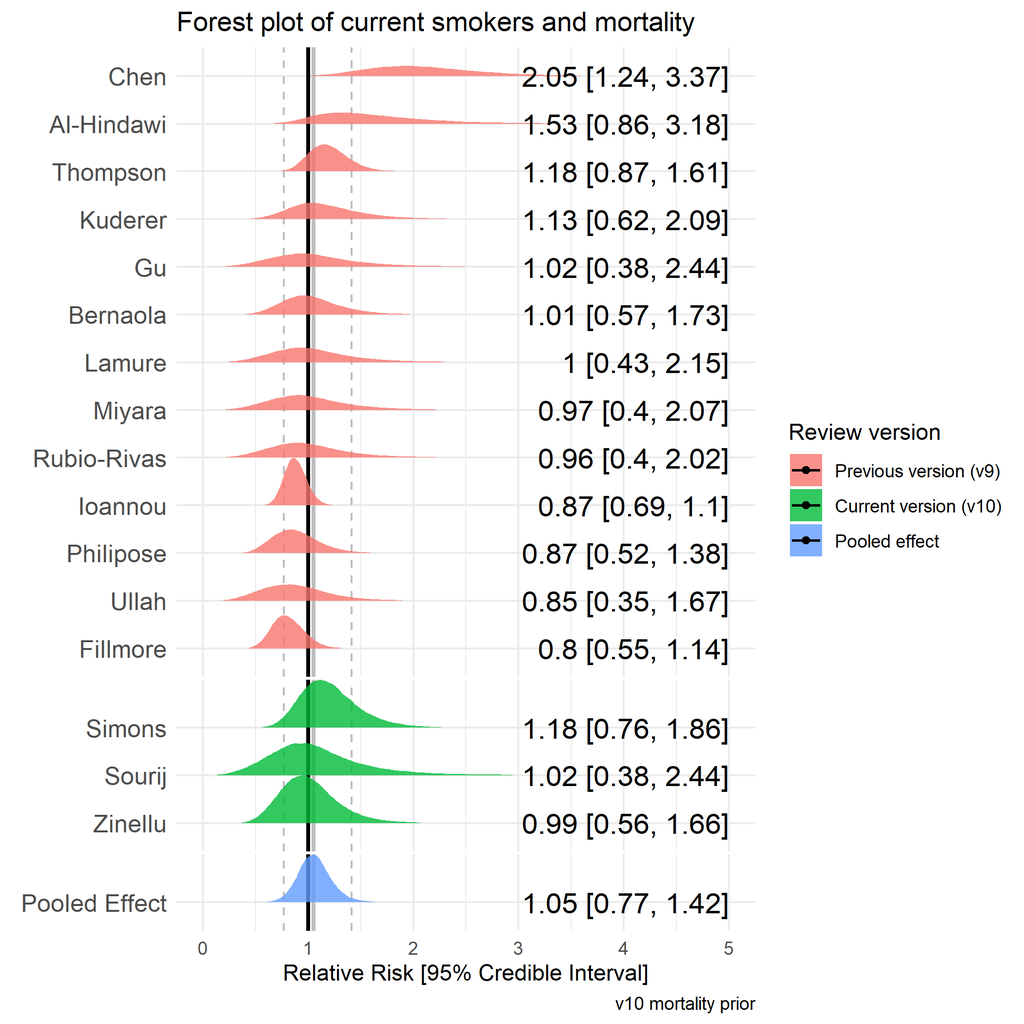

Figure 9. Forest plot for the risk of mortality in current vs. never smokers. The prior from the previous review version (v9) was RR = 1.05.

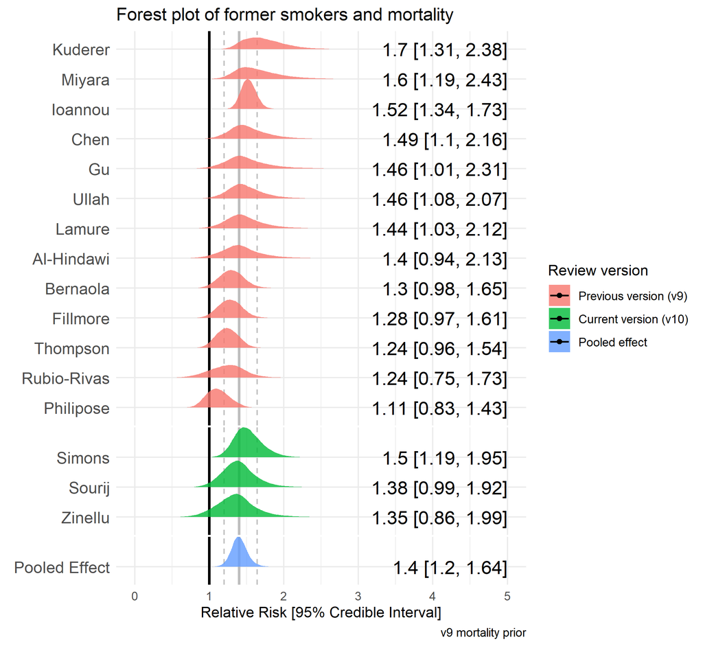

Figure 10. Forest plot for the risk of mortality in former smokers vs. never smokers. The prior from the previous version (v9) was RR = 1.39.

## Discussion

This living rapid review found uncertainty in the majority of 345 studies arising from the recording of smoking status. Notwithstanding these uncertainties, compared with overall adult national prevalence estimates, recorded current smoking rates in most studies were lower than expected. In a subset of better-quality studies (n = 27), current but not former smokers had a reduced risk of testing positive for SARS-CoV-2 but current smokers appeared somewhat more likely to present for testing and/or receive a test. Data for current smokers on the risk of hospitalisation, disease severity and mortality were inconclusive, and favoured there being no important associations with hospitalisation and mortality and a small but important increase in the risk of severe disease. Former smokers were at increased risk of hospitalisation, disease severity and mortality compared with never smokers. Issues complicating interpretation

Interpretation of results from studies conducted during the first phase of the SARS-CoV-2 pandemic is complicated by several factors (see Figure 11):

1. *Exposure to SARS-CoV-2*  
   1. Exposure to the SARS-CoV-2 virus is heterogeneous with different subgroups at heightened risk of infection at different stages of the pandemic, at least partly due to differential contact matrices by age, sex and socioeconomic position (CMMID COVID-19 working group et al. 2020), which are associated with smoking status.  
   2. The probability of viral exposure depends largely on local prevalence, which varies over time. This likely introduces bias in studies assessing the rate of infection by smoking status conducted in the early phase of the pandemic.
2. *Infection with SARS-CoV-2*  
   1. Infection following viral exposure depends on individual differences in, for example, genetic susceptibility or immunocompetence, which are poorly understood at present. For example, the household secondary attack rate for COVID-19 is estimated at 17% (Fung et al. 2020).  
   2. Heated and humidified air may act to disrupt the ability of the virus to persist in the airway mucosa of smokers. There is some evidence that transient localised hyperthermia can inhibit replication of rhinoviruses, a non-enveloped virus that causes the common cold (Conti et al. 1999). However, as SARS-CoV-2 is an enveloped virus (Schoeman and Fielding 2019), it is unclear whether a similar protective effect against viral replication or invasion by heated and humidified air may occur.
3. *Symptomatic COVID-19*  
   1. An estimated 20% (95% CI = 17-25%) of COVID-19 cases are asymptomatic (Buitrago-Garcia et al. 2020), with some evidence suggesting younger people are more likely to be asymptomatic (Kronbichler et al. 2020). Testing is hence likely limited in some subgroups, with the potential for these groups to include an overrepresentation of current smokers. 2. Current and former smokers may be more likely to meet local criteria for community testing due to increased prevalence of symptoms consistent with SARS-CoV-2 infection, such as cough, increased sputum production or altered sense of smell or taste (Hopkinson et al. 2020). Evidence from a small number of studies indicates that current smokers may be more likely to present for testing, hence increasing the denominator in comparisons with never smokers and potentially inflating the rate of negative tests in current smokers. Infection positivity rates estimated among random samples are more informative. We identified one population study conducted in Hungary reporting on seroprevalence and smoking status (Merkely et al. 2020); however, the response rate was only 58.8% and the current smoking rate was 10 percentage points below national prevalence estimates, which raises some doubt about representativeness of the final sample. Similarly, a second representative population survey with results from three regions in France (Carrat et al. 2020) reported a current smoking rate of more than 10 percentage points below national prevalence (12% vs. 25% daily smoking prevalence) (Andler 2019).
4. *Testing positive for SARS-CoV-2*  
   1. Smokers with COVID-19 may be less likely to receive a SARS-CoV-2 test or present to hospital due to lack of access to healthcare and may be more likely to die in the community from sudden complications (i.e. self-selection bias) and thus not be recorded (*STS Top Line Findings_Sep 20.pptx*, n.d.). 2. Diagnostic criteria for SARS-CoV-2 infection and COVID-19 have changed during the course of the pandemic (Organisation, n.d.). It was not possible to extract details on the specific RT-PCR or antibody-based techniques or platforms used across the included studies due to reporting gaps. Different platforms have varying sensitivity and specificity to detect SARS-CoV-2 infection. In addition, testing for acute infection requires swabbing of the mucosal epithelium, which may be disrupted in current smokers, potentially altering the sensitivity of assays (Lusignan et al. 2020).
5. *Hospitalisation with COVID-19*  
   1. Reasons for hospitalisation vary by country and time in the pandemic. For example, early cases may have been hospitalised for isolation and quarantine reasons and not due to medical necessity. It is plausible this may have skewed early data towards less severe cases. In addition, the observed association between former smoking and greater disease severity may be explained by collider bias49, where conditioning on a collider (e.g. testing or hospitalisation) by design or analysis may introduce a spurious association between current or former smoking (a potential cause of testing or hospitalisation) and SARS-CoV-2 infection/adverse outcomes from COVID-19 (potentially exacerbated by smoking) (Murray 2020). 2. The majority of included studies relied on EHRs as the source of information on smoking status. Research shows large discrepancies between EHRs and actual behaviour (Polubriaginof et al. 2018). Known failings of EHRs include implausible longitudinal changes, such as former smokers being recorded as never smokers at subsequent hospital visits51. Misreporting on the part of the patient (perhaps due to perceived stigma) has also been observed, with biochemical measures showing higher rates of smoking compared with self-report in hospitalised patients in the US (Benowitz et al. 2009). It is hence possible that under-reporting of current and former smoking status in hospitals occurred across the included studies. 3. The majority of included studies were conducted in hospital settings. It is plausible that a non-trivial proportion of patients were infected with SARS-CoV-2 while being an inpatient for a different medical reason. If so, this may have biased the hospitalised populations towards older and more frail groups, who are less likely to be smokers (Mangera et al. 2017). 4. Individuals with severe COVID-19 symptoms may have stopped smoking immediately before admission to hospital and may therefore not have been recorded as current smokers (i.e. reverse causality).
6. *COVID-19 disease severity and death*  
   1. Given lack of knowledge of the disease progression and long-term outcomes of COVID-19, it is unclear whether studies conducted thus far in the pandemic have monitored patients for a sufficient time period to report complete survival outcomes or whether they are subject to early censoring. Adding to this, COVID-19 related mortality has been differentially defined across countries and epidemic phases. For example, in some UK reporting, death within 28 days of a COVID-19 diagnosis is required for attributing the cause of death to the virus. However, according to the UK Office for National Statistics, COVID-19 deaths are recorded only if this was stated on the death certificate. 2. If there is a protective effect of nicotine on COVID-19 disease outcomes, abrupt nicotine withdrawal upon hospitalisation may lead to worse disease outcomes including death (Farsalinos et al. 2020). 3. During periods of heightened demand of limited healthcare resources, current and former smokers with extensive comorbidities may have reduced priority for intensive care admission, thus leading to higher in-hospital mortality. 4. COVID-19 outcomes are currently limited to in-hospital death or survival to discharge. This binary outcome does not capture potential long-term morbidity attributed to COVID-19, such as stroke, amputation or acute cardiac events, which may be moderated by smoking status.

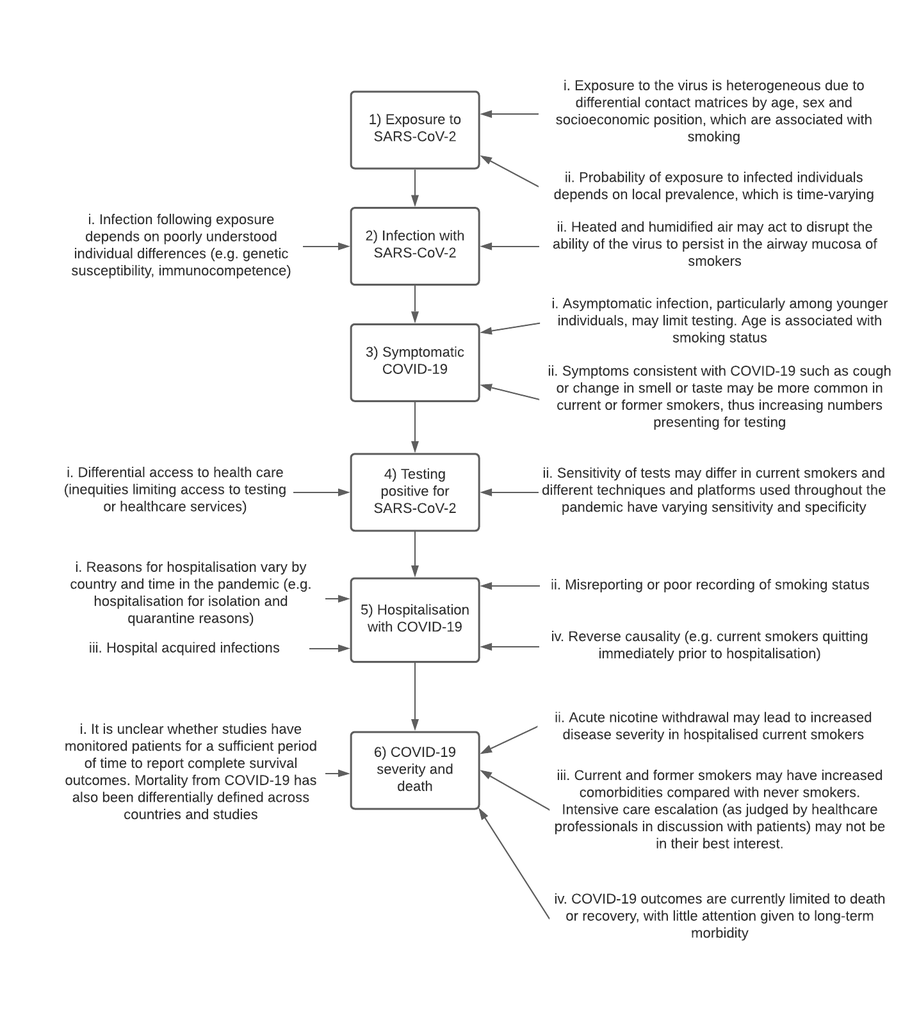

*Figure 11.* A schematic of some of the interpretation issues for the association of smoking status and COVID-19 infection, hospitalisation, disease severity and mortality. Numbers refer to the issues listed in-text in the above section. Issues presented on the right-hand side relate directly to smoking status.

### Limitations

This living rapid evidence review was limited by having a single reviewer extracting data with a second independently verifying the data extracted to minimise errors, restricting the search to one electronic database and one pre-print server and by not including at least three large population surveys due to their reliance on self-reported suspected or confirmed SARS-CoV-2 infection (which means they do not meet our eligibility criteria) (Hopkinson et al. 2020; Bowyer et al. 2020; Jackson et al. 2020). We also did not include a large, UK-based, representative seroprevalence study (Ward et al. 2020) in our meta-analyses as the odds of testing positive in former smokers was not reported. However, the odds of infection for current smokers (OR = 0.64, 95% CI = 0.58-0.71) was in concordance with the pooled estimate in our meta-analysis. Population surveys – particularly with linked data on confirmed infection or antibodies – will be included in future review versions to help mitigate some of the limitations of healthcare based observational studies. The comparisons of current and former smoking prevalence in the included studies with national prevalence estimates did not adjust observed prevalence for the demographic profile of those tested/admitted to hospital. Other reviews focused on this comparison have applied adjustments for sex and age, and continue to find lower than expected prevalence – notwithstanding the issues complicating interpretation described above17.

### Implications for research, policy and practice

Further scientific research is needed to resolve the mixed findings summarised in our review. First, clinical trials of the posited therapeutic effect of nicotine could have important implications both for smokers and for improved understanding of how the SARS-CoV-2 virus causes disease in humans. Such trials should focus on medicinal nicotine (as smoked tobacco is a dirty delivery mechanism that could mask beneficial effects) and potentially differentiate between different modes of delivery (i.e. inhaled vs. ingested) since this can affect pharmacokinetics (Shahab, Brose, and West 2013) and potential therapeutic effects. A second research priority would be a large, representative (randomly sampled) population survey with a validated assessment of smoking status which distinguishes between recent and long-term ex-smokers – ideally biochemically verified – and assesses seroprevalence and links to health records.

In the meantime, public-facing messages about the possible protective effect of smoking or nicotine are premature. In our view, until there is further research, the quality of the evidence does not justify the huge risk associated with a message likely to reach millions of people that a lethal activity, such as smoking, may protect against COVID-19. It continues to be appropriate to recommend smoking cessation and emphasise the role of alternative nicotine products to support smokers to stop as part of public health efforts during COVID-19. At the very least, smoking cessation reduces acute risks from cardiovascular disease and could reduce demands on the healthcare system (Stead et al. 2013). GPs and other healthcare providers can play a crucial role – brief, high-quality and free online training is available at [National Centre for Smoking Cessation and Training](https://www.ncsct.co.uk/).

## Conclusion

Across 345 studies, recorded current but not past smoking prevalence was generally lower than national prevalence estimates. Current smokers were at reduced risk of testing positive for SARS-CoV-2 and former smokers were at increased risk of hospitalisation, disease severity and mortality compared with never smokers.

## Acknowledgements

An original short review for the Royal College of Physicians was converted to an extended living review after a request by Martin Dockrell, Tobacco Control Lead, Public Health England. All scientific decisions were made by the authors independently of funders and external organisations. The authors would like to thank Rosemary Koper for her assistance in running the electronic searches and data extraction up until v7, and all authors who responded to requests for additional data.

## Declaration of conflicts of interest

DS and OP have no conflicts of interest to declare. LS has received a research grant and honoraria for a talk and travel expenses from manufacturers of smoking cessation medications (Pfizer and Johnson & Johnson). JB has received unrestricted research funding to study smoking cessation from companies who manufacture smoking cessation medications. All authors declare no financial links with tobacco companies or e-cigarette manufacturers or their representatives.

## Funding statement

DS is supported by a PhD studentship from the UK Biotechnology and Biological Sciences Research Council [BB/M009513/1]. OP receives salary support from Cancer Research UK (C1417/A22962). JB, LS, & OP are members of SPECTRUM, a UK Prevention Research Partnership Consortium (MR/S037519/1). UKPRP is an initiative funded by the UK Research and Innovation Councils, the Department of Health and Social Care (England) and the UK devolved administrations, and leading health research charities.

## Review versions

The most up-to-date review version is available [here](https://www.qeios.com/read/latest-UJR2AW)

### Previous review versions

- [Version 1](https://doi.org/10.32388/UJR2AW)
- [Version 2](https://doi.org/10.32388/UJR2AW.3)
- [Version 3](https://doi.org/10.32388/UJR2AW.4)
- [Version 4](https://doi.org/10.32388/UJR2AW.5)
- [Version 5](https://doi.org/10.32388/UJR2AW.6)
- [Version 6](https://doi.org/10.32388/UJR2AW.7)
- [Version 7](https://doi.org/10.1111/add.15276)
- [Version 8](https://doi.org/10.32388/UJR2AW.9)
- [Version 9](https://doi.org/10.32388/UJR2AW.10)

## Data availability

All data contributing to the current and future review versions are available [here](https://doi.org/10.6084/m9.figshare.12756020) All code required to reproduce the current and future analyses are available [here](https://doi.org/10.5281/zenodo.4002046)

## References

Abadom, Tochukwu Raphael, Adrian D. Smith, Stefano Tempia, Shabir A. Madhi, Cheryl Cohen, and Adam L. Cohen. 2016. “Risk Factors Associated with Hospitalisation for Influenza-Associated Severe Acute Respiratory Illness in South Africa: A Case-Population Study.” *Vaccine* 34 (46): 5649–55. https://doi.org/10.1016/j.vaccine.2016.09.011.

Abolghasemi, Sara, Masoud Mardani, Shahnaz Sali, Negin Honarvar, and Mana Baziboroun. 2020. “COVID‐19 and Kidney Transplant Recipients.” *Transplant Infectious Disease* 22 (6). https://doi.org/10.1111/tid.13413.

Adrish, Muhammad, Sridhar Chilimuri, Nikhitha Mantri, Haozhe Sun, Maleeha Zahid, Sudharsan Gongati, Ked Fortuzi, Abhishrut Pramod Jog, Pravish Purmessur, and Ravish Singhal. 2020. “Association of Smoking Status with Outcomes in Hospitalised Patients with COVID-19.” *BMJ Open Respiratory Research* 7 (1): e000716. https://doi.org/10.1136/bmjresp-2020-000716.

Aksu, K., T. Naziroğlu, and P. Özkan. 2020. “Factors Determining COVID‐19 Pneumonia Severity in a Country with Routine BCG Vaccination.” *Clinical & Experimental Immunology* 202 (2): 220–25. https://doi.org/10.1111/cei.13507.

Alguwaihes, Abdullah M., Mohammed E. Al-Sofiani, Maram Megdad, Sakhar S. Albader, Mohammad H. Alsari, Ali Alelayan, Saad H. Alzahrani, Shaun Sabico, Nasser M. Al-Daghri, and Anwar A. Jammah. 2020. “Diabetes and Covid-19 Among Hospitalized Patients in Saudi Arabia: A Single-Centre Retrospective Study.” *Cardiovascular Diabetology* 19 (1): 205. https://doi.org/10.1186/s12933-020-01184-4.

Alharthy, Abdulrahman, Waleed Aletreby, Fahad Faqihi, Abdullah Balhamar, Feisal Alaklobi, Khaled Alanezi, Parameaswari Jaganathan, et al. 2020. “Clinical Characteristics and Predictors of 28-Day Mortality in 352 Critically Ill Patients with COVID-19: A Retrospective Study:” *Journal of Epidemiology and Global Health*. https://doi.org/10.2991/jegh.k.200928.001.

Al-Hindawi, Ahmed, Jagdish Sokhi, Joshua Cuddihy, Christopher Lockie, Linsey Christie, Roger Davies, Suveer Singh, et al. 2020. “COVID-19 in London, a Case Series Demonstrating Late Improvement in Survivors.” *medRxiv*, May, 2020.05.16.20103853. https://doi.org/10.1101/2020.05.16.20103853.

Alizadehsani, Roohallah, Zahra Alizadeh Sani, Mohaddeseh Behjati, Zahra Roshanzamir, Sadiq Hussain, Niloofar Abedini, Fereshteh Hasanzadeh, et al. 2020. “Risk Factors Prediction, Clinical Outcomes, and Mortality of COVID-19 Patients.” *medRxiv*, July, 2020.07.07.20148569. https://doi.org/10.1101/2020.07.07.20148569.

Alkurt, Gizem, Ahmet Murt, Zeki Aydin, Ozge Tatli, Nihat Bugra Agaoglu, Arzu Irvem, Mehtap Aydin, et al. 2020. “Seroprevalence of Coronavirus Disease 2019 (COVID-19) Among Health Care Workers from Three Pandemic Hospitals of Turkey.” *medRxiv*, August, 2020.08.19.20178095. https://doi.org/10.1101/2020.08.19.20178095.

Allenbach, Yves, David Saadoun, Georgina Maalouf, Matheus Vieira, Alexandra Hellio, Jacques Boddaert, Hélène Gros, et al. 2020. “Development of a Multivariate Prediction Model of Intensive Care Unit Transfer or Death: A French Prospective Cohort Study of Hospitalized COVID-19 Patients.” Edited by José Moreira. *PLOS ONE* 15 (10): e0240711. https://doi.org/10.1371/journal.pone.0240711.

Almazeedi, Sulaiman, Sarah Al-Youha, Mohammad H. Jamal, Mohannad Al-Haddad, Ali Al-Muhaini, Fahad Al-Ghimlas, and Salman Al-Sabah. 2020. “Characteristics, Risk Factors and Outcomes Among the First Consecutive 1096 Patients Diagnosed with COVID-19 in Kuwait.” *EClinicalMedicine* 24 (July): 100448. https://doi.org/10.1016/j.eclinm.2020.100448.

Almirall, J., C. A. González, X. Balanzó, and I. Bolíbar. 1999. “Proportion of Community-Acquired Pneumonia Cases Attributable to Tobacco Smoking.” *Chest* 116: 375–9. https://doi.org/10.1378/chest.116.2.375.

Alqahtani, Jaber S, Tope Oyelade, Abdulelah M Aldhahir, Saeed M Alghamdi, Mater Almehmadi, Abdullah S Alqahtani, Shumonta Quaderi, Swapna Mandal, and John Hurst. 2020. “Prevalence, Severity and Mortality Associated with COPD and Smoking in Patients with COVID-19: A Rapid Systematic Review and Meta-Analysis.” *medRxiv*, 2020.03.25.20043745. https://doi.org/10.1101/2020.03.25.20043745.

Alshami, Alanoud A., Rabab A. Alattas, Hadeel F. Anan, Hadi S. Al Qahtani, Mobarak A. Al Mulhim, Abdulbari A. Alahilmi, and Ahmed H. Alfaraj. 2020. “Silent Disease and Loss of Taste and Smell Are Common Manifestations of SARS-COV-2 Infection in a Quarantine Facility: First Report from Saudi Arabia.” *medRxiv*, May, 2020.05.13.20100222. https://doi.org/10.1101/2020.05.13.20100222.

Altamimi, Hassan, Yasser Alahmad, Fadi Khazal, Mowahib Elhassan, Hajar AlBinali, Abdulrahman Arabi, Awad AlQahtani, et al. 2020. “The Outcome of COVID-19 Patients with Acute Myocardial Infarction.” *medRxiv*, July, 2020.07.21.20156349. https://doi.org/10.1101/2020.07.21.20156349.

Altibi, Ahmed M., Pallavi Bhargava, Hassan Liaqat, Alexander A. Slota, Radhika Sheth, Lama Al Jebbawi, Matthew E. George, et al. 2020. “Comparative Clinical Outcomes and Mortality in Prisoner and Non-Prisoner Populations Hospitalized with COVID-19: A Cohort from Michigan.” *medRxiv*, August, 2020.08.08.20170787. https://doi.org/10.1101/2020.08.08.20170787.

Andler, Raphaël. 2019. “BAISSE DE LA PRÉVALENCE DU TABAGISME QUOTIDIEN PARMI LES ADULTES : RÉSULTATS DU BAROMÈTRE DE SANTÉ PUBLIQUE FRANCE 2018 / REDUCTION OF DAILY SMOKING RATE AMONG ADULTS: RESULTS FROM THE 2018 SANTÉ PUBLIQUE FRANCE HEALTH BAROMETER,” 7.

Antonio-Villa, Neftali Eduardo, Omar Yaxmehen Bello-Chavolla, Arsenio Vargas-Vazquez, Carlos A. Fermin-Martinez, Alejandro Marquez-Salinas, and Jessica Paola Bahena-Lopez. 2020. “Health-Care Workers with COVID-19 Living in Mexico City: Clinical Characterization and Related Outcomes.” *medRxiv*, July, 2020.07.02.20145169. https://doi.org/10.1101/2020.07.02.20145169.

Apea, Vanessa J., Yize I. Wan, Rageshri Dhairyawan, Zudin A. Puthucheary, Rupert M. Pearse, Chloe M. Orkin, and John R. Prowle. 2020. “Ethnicity and Outcomes in Patients Hospitalised with COVID-19 Infection in East London: An Observational Cohort Study.” *medRxiv*, June, 2020.06.10.20127621. https://doi.org/10.1101/2020.06.10.20127621.

Argenziano, Michael G, Samuel L Bruce, Cody L Slater, Jonathan R Tiao, Matthew R Baldwin, R Graham Barr, Bernard P Chang, et al. 2020. “Characterization and Clinical Course of 1000 Patients with Coronavirus Disease 2019 in New York: Retrospective Case Series.” *BMJ*, May, m1996. https://doi.org/10.1136/bmj.m1996.

Ariza, Beatriz Elena, Yulieth Ximena Torres, Diana Salgado, Magda Cepeda, Carlos Gomez, Julio Cesar Castellanos, Fernando Suarez, et al. 2020. “Seroprevalence and Seroconversion Rates to SARS-CoV-2 in Interns, Residents, and Medical Doctors in a University Hospital in Bogota, Colombia.” *medRxiv*, September, 2020.09.15.20195313. https://doi.org/10.1101/2020.09.15.20195313.

Arleo, Timothy, David Tong, Julie Shabto, Ghazala O’Keefe, and Arezou Khosroshahi. 2020. “Clinical Course and Outcomes of Coronavirus Disease 2019 (COVID-19) in Rheumatic Disease Patients on Immunosuppression: A Case Cohort Study at a Single Center with a Significantly Diverse Population.” Preprint. Epidemiology. https://doi.org/10.1101/2020.10.26.20219154.

Auvinen, Raija, Hanna Nohynek, Ritva Syrjänen, Jukka Ollgren, Tuija Kerttula, Jarkko Mäntylä, Niina Ikonen, et al. 2020. “Comparison of the Clinical Characteristics and Outcomes of Hospitalized Adult COVID-19 and Influenza Patients: A Prospective Observational Study.” *medRxiv*, June, 2020.06.29.20140632. https://doi.org/10.1101/2020.06.29.20140632.

Barasa, Samson, Josephine Kiage-Mokaya, Katya Cruz-Madrid, and Michael Friedlander. 2020. “Smoking Increases the Risk of COVID-19 Positivity, While Never-Smoking Reduces the Risk.” Preprint. Respiratory Medicine. https://doi.org/10.1101/2020.11.30.20241380.

Basse, Clemence, Sarah Diakite, Vincent Servois, Maxime Frelaut, Aurelien Noret, Audrey Bellesoeur, Pauline Moreau, et al. 2020. “Characteristics and Outcome of SARS-CoV-2 Infection in Cancer Patients.” *medRxiv*, May, 2020.05.14.20101576. https://doi.org/10.1101/2020.05.14.20101576.

Batty, George David, Ian Deary, Michelle Luciano, Drew Altschul, Mika Kivimaki, and Catharine Gale. 2020. “Psychosocial Factors and Hospitalisations for COVID-19: Prospective Cohort Study of the General Population.” *medRxiv*, June, 2020.05.29.20100735. https://doi.org/10.1101/2020.05.29.20100735.

Bellan, Mattia, Giuseppe Patti, Eyal Hayden, Danila Azzolina, Mario Pirisi, Antonio Acquaviva, Gianluca Aimaretti, et al. 2020. “Fatality Rate and Predictors of Mortality in an Italian Cohort of Hospitalized COVID-19 Patients.” *Scientific Reports* 10 (1): 20731. https://doi.org/10.1038/s41598-020-77698-4.

Bello-Chavolla, Omar Yaxmehen, Neftali Eduardo Antonio-Villa, Arsenio Vargas-Vázquez, Carlos A. Fermín-Martínez, Alejandro Márquez-Salinas, and Jessica Paola Bahena-López. 2020. “Profiling Pre-Symptomatic and Asymptomatic Cases with Confirmed SARS-CoV-2 Infection in Mexico City.” *medRxiv*, July, 2020.07.02.20145516. https://doi.org/10.1101/2020.07.02.20145516.

Bello-Chavolla, Omar Yaxmehen, Jessica Paola Bahena-López, Neftali Eduardo Antonio-Villa, Arsenio Vargas-Vázquez, Armando González-Díaz, Alejandro Márquez-Salinas, Carlos A. Fermín-Martínez, J. Jesús Naveja, and Carlos A. Aguilar-Salinas. 2020. “Predicting Mortality Due to SARS-CoV-2: A Mechanistic Score Relating Obesity and Diabetes to COVID-19 Outcomes in Mexico.” *The Journal of Clinical Endocrinology & Metabolism* 105 (8). https://doi.org/10.1210/clinem/dgaa346.

Benaim, Anat Reiner, Jonathan Aryeh Sobel, Ronit Almog, Snir Lugassy, Tsviel Ben Shabbat, Alistair Johnson, Danny Eytan, and Joachim A. Behar. 2020. “At the Dawn of Winter: Comparing COVID-19 and Influenza Presentation and Trajectory.” Preprint. Infectious Diseases (except HIV/AIDS). https://doi.org/10.1101/2020.11.19.20235077.

Benowitz, Neal L., Katherine E. Schultz, Christine A. Haller, Alan H. B. Wu, Katherine M. Dains, and Peyton Jacob. 2009. “Prevalence of Smoking Assessed Biochemically in an Urban Public Hospital: A Rationale for Routine Cotinine Screening.” *American Journal of Epidemiology* 170 (7): 885–91. https://doi.org/10.1093/aje/kwp215.

Berlin, Ivan, Daniel Thomas, Anne-Laurence Le Faou, and Jacques Cornuz. 2020. “COVID-19 and Smoking.” *Nicotine & Tobacco Research*. https://doi.org/10.1093/NTR/NTAA059.

Bermejo-Martin, Jesús F., Milagros González-Rivera, Raquel Almansa, Dariela Micheloud, Ana P. Tedim, Marta Domínguez-Gil, Salvador Resino, et al. 2020. “Viral RNA Load in Plasma Is Associated with Critical Illness and a Dysregulated Host Response in COVID-19.” *Critical Care* 24 (1): 691. https://doi.org/10.1186/s13054-020-03398-0.

Bernaola, Nikolas, Raquel Mena, Ander Bernaola, Antonio Lara, Cesar Carballo, Pedro Larranaga, and Concha Bielza. 2020. “Observational Study of the Efficiency of Treatments in Patients Hospitalized with Covid-19 in Madrid.” *medRxiv*, July, 2020.07.17.20155960. https://doi.org/10.1101/2020.07.17.20155960.

Berumen, Jaime, Max Schmulson, Jesus Alegre, Guadalupe Guerrero, Gustavo Olaiz, Rosa M. Wong-Chew, Jorge Larriva-Sahd, et al. 2020. “Risk of Infection and Hospitalization by Covid-19 in Mexico: A Case-Control Study.” *medRxiv*, May, 2020.05.24.20104414. https://doi.org/10.1101/2020.05.24.20104414.

Best, Jennie H., Shalini V. Mohan, Amanda M. Kong, Krish Patel, John M. Pagel, Boris Ivanov, Otis W. Brawley, Krutika Jariwala-Parikh, James L. Zazzali, and John Pauk. 2020. “Baseline Demographics and Clinical Characteristics Among 3471 US Patients Hospitalized with COVID-19 and Pulmonary Involvement: A Retrospective Study.” *Advances in Therapy* 37 (12): 4981–95. https://doi.org/10.1007/s12325-020-01510-y.

Bian, Huijie, Zhao-Hui Zheng, Ding Wei, Zheng Zhang, Wen-Zhen Kang, Chun-Qiu Hao, Ke Dong, et al. 2020. “Meplazumab Treats COVID-19 Pneumonia: An Open-Labelled, Concurrent Controlled Add-on Clinical Trial.” *medRxiv*, July, 2020.03.21.20040691. https://doi.org/10.1101/2020.03.21.20040691.

Bisso, Indalecio Carboni, Iván Huespe, Carolina Lockhart, Agustín Massó, Julieta González Anaya, Micaela Hornos, Romina Famiglietti, et al. 2020. “Clinical Characteristics of Critically Ill Patients with COVID-19.” Preprint. Intensive Care; Critical Care Medicine. https://doi.org/10.1101/2020.12.09.20246413.

Borobia, Alberto M., Antonio J. Carcas, Francisco Arnalich, Rodolfo Álvarez-Sala, Jaime Monserrat-Villatoro, Manuel Quintana, Juan Carlos Figueira, et al. 2020. “A Cohort of Patients with COVID-19 in a Major Teaching Hospital in Europe.” *Journal of Clinical Medicine* 9 (6): 1733. https://doi.org/10.3390/jcm9061733.

Boulware, David R., Matthew F. Pullen, Ananta S. Bangdiwala, Katelyn A. Pastick, Sarah M. Lofgren, Elizabeth C. Okafor, Caleb P. Skipper, et al. 2020. “A Randomized Trial of Hydroxychloroquine as Postexposure Prophylaxis for Covid-19.” *New England Journal of Medicine*, June. https://doi.org/10.1056/NEJMoa2016638.

Bowyer, Ruth C E, Thomas Varsavsky, Carole H. Sudre, Benjamin A K Murray, Maxim B Freidin, Darioush Yarand, Sajaysurya Ganesh, et al. 2020. “Geo-Social Gradients in Predicted COVID-19 Prevalence and Severity in Great Britain: Results from 2,266,235 Users of the COVID-19 *Symptoms Tracker App*,” April. https://doi.org/10.1101/2020.04.23.20076521.

Brake, S. J., K. Barnsley, W. Lu, K. D. McAlinden, M. S. Eapen, and S. S. Sohal. 2020. “Smoking Upregulates Angiotensin-Converting Enzyme-2 Receptor: A Potential Adhesion Site for Novel Coronavirus SARS-CoV-2 (Covid-19).” *J Clin Med* 9, Page 841: 841. https://doi.org/10.3390/jcm9030841.

Buitrago-Garcia, Diana, Dianne Egli-Gany, Michel J. Counotte, Stefanie Hossmann, Hira Imeri, Aziz Mert Ipekci, Georgia Salanti, and Nicola Low. 2020. “Occurrence and Transmission Potential of Asymptomatic and Presymptomatic SARS-CoV-2 Infections: A Living Systematic Review and Meta-Analysis.” *PLOS Medicine* 17 (9): e1003346. https://doi.org/10.1371/journal.pmed.1003346.

Burrell, Aidan JC, Breanna Pellegrini, Farhad Salimi, Husna Begum, Tessa Broadley, Lewis T. Campbell, Allen C. Cheng, et al. 2020. “Outcomes of COVID-19 Patients Admitted to Australian Intensive Care Units During the Early Phase of the Pandemic.” *The Medical Journal of Australia*, September, 1. https://doi.org/10.5694/mja2.50883.

Bürkner, Paul-Christian. 2018. “Advanced Bayesian Multilevel Modeling with the R Package Brms.” *The R Journal* 10 (1): 395. https://doi.org/10.32614/RJ-2018-017.

Cadegiani, Flávio Adsuara, John McCoy, Carlos Gustavo Wambier, and Andy Goren. 2020. “5-Alpha-Reductase Inhibitors Reduce Remission Time of COVID-19: Results from a Randomized Double Blind Placebo Controlled Interventional Trial in 130 SARS-CoV-2 Positive Men.” Preprint. Infectious Diseases (except HIV/AIDS). https://doi.org/10.1101/2020.11.16.20232512.

Cai, Guoshuai. 2020. “Bulk and Single-Cell Transcriptomics Identify Tobacco-Use Disparity in Lung Gene Expression of ACE2, the Receptor of 2019-nCov.” https://doi.org/10.20944/PREPRINTS202002.0051.V3.

Carrat, Fabrice, Xavier de Lamballerie, Delphine Rahib, Helene Blanche, Nathanael Lapidus, Fanny Artaud, Sofiane Kab, et al. 2020. “Seroprevalence of SARS-CoV-2 Among Adults in Three Regions of France Following the Lockdown and Associated Risk Factors: A Multicohort Study.” *medRxiv*, September, 2020.09.16.20195693. https://doi.org/10.1101/2020.09.16.20195693.

Carrillo-Vega, Maria Fernanda, Guillermo Salinas-Escudero, Carmen Garcia-Peña, Luis Miguel Gutierrez-Robledo, and Lorena Parra-Rodriguez. 2020. “Early Estimation of the Risk Factors for Hospitalisation and Mortality by COVID-19 in Mexico.” *medRxiv*, May, 2020.05.11.20098145. https://doi.org/10.1101/2020.05.11.20098145.

CDCMMWR. 2020. “Preliminary Estimates of the Prevalence of Selected Underlying Health Conditions Among Patients with Coronavirus Disease 2019 — United States, February 12–March 28, 2020.” *MMWR. Morbidity and Mortality Weekly Report* 69. https://doi.org/10.15585/mmwr.mm6913e2.

Cen, Y., X. Chen, Y. Shen, X.-H. Zhang, Y. Lei, C. Xu, W.-R. Jiang, et al. 2020. “Risk Factors for Disease Progression in Patients with Mild to Moderate Coronavirus Disease 2019—a Multi-Centre Observational Study.” *Clinical Microbiology and Infection*, June, S1198743X20303414. https://doi.org/10.1016/j.cmi.2020.05.041.

Chand, Sudham, Sumit Kapoor, Deborah Orsi, Melissa J. Fazzari, Tristan G. Tanner, Genevieve C. Umeh, Marjan Islam, and Peter V. Dicpinigaitis. 2020. “COVID-19-Associated Critical Illness—Report of the First 300 Patients Admitted to Intensive Care Units at a New York City Medical Center:” *Journal of Intensive Care Medicine*, August. https://doi.org/10.1177/0885066620946692.

Chaudhary, Ashok, Uday Narayan Singh, Pramod Paudel, Niresh Thapa, Kamal Khadka, Prameshwar Kumar Sah, Sher Bahadur Kamar, et al. 2020. “Characteristics and Outcomes of Hospitalized Adults with COVID-19 in Nepal: A Multicenter, Prospective Cohort Study.” *medRxiv*, October, 2020.10.03.20206128. https://doi.org/10.1101/2020.10.03.20206128.

Chaudhry, Farhan, Helena Bulka, Anirudha S. Rathnam, Omar M. Said, Jia Lin, Holly Lorigan, Evanthia Bernitsas, et al. 2020. “COVID-19 in Multiple Sclerosis Patients and Risk Factors for Severe Infection.” *medRxiv*, May, 2020.05.27.20114827. https://doi.org/10.1101/2020.05.27.20114827.

Chen, Cheng, Jie Jiang, Xiaoxiao Xu, Yiyang Hu, Yi Hu, and Yu Zhao. 2020. “Dynamic Liver Function Indexes Monitoring and Clinical Characteristics in Three Types of COVID-19 Patients.” *medRxiv*, May, 2020.05.13.20099614. https://doi.org/10.1101/2020.05.13.20099614.

Chen, Haotian, Yogatheesan Varatharajah, Sarah Stewart de Ramirez, Paul Arnold, Casey Frankenberger, Bala Hota, and Ravishankar Iyer. 2020. “A Retrospective Longitudinal Study of COVID-19 as Seen by a Large Urban Hospital in Chicago.” Preprint. Infectious Diseases (except HIV/AIDS). https://doi.org/10.1101/2020.11.29.20240606.

Chen, Lei, Jianming Yu, Wenjuan He, Li Chen, Guolin Yuan, Fang Dong, Wenlan Chen, et al. 2020. “Risk Factors for Death in 1859 Subjects with COVID-19.” *Leukemia*, June, 1–11. https://doi.org/10.1038/s41375-020-0911-0.

Chen, Tao, Di Wu, Huilong Chen, Weiming Yan, Danlei Yang, Guang Chen, Ke Ma, et al. 2020. “Clinical Characteristics of 113 Deceased Patients with Coronavirus Disease 2019: Retrospective Study.” *BMJ* 368 (March). https://doi.org/10.1136/bmj.m1091.

Cho, Eo Rin, Arthur S. Slutsky, and Prabhat Jha. 2020. “Smoking and the Risk of COVID-19 Infection in the UK Biobank Prospective Study.” *medRxiv*, May, 2020.05.05.20092445. https://doi.org/10.1101/2020.05.05.20092445.

Chudasama, Yogini V, Francesco Zaccardi, Clare L Gillies, Cameron Razieh, Thomas Yates, David E Kloecker, Alex V Rowlands, et al. 2020. “Patterns of Multimorbidity and Risk of Severe SARS-CoV-2 Infection: An Observational Study in the U.K.” Preprint. Epidemiology. https://doi.org/10.1101/2020.10.21.20216721.

Clavario, Piero, Vincenzo De Marzo, Roberta Lotti, Cristina Barbara, Annalisa Porcile, Carmelo Russo, Federica Beccaria, et al. 2020. “Assessment of Functional Capacity with Cardiopulmonary Exercise Testing in Non-Severe COVID-19 Patients at Three Months Follow-up.” Preprint. Cardiovascular Medicine. https://doi.org/10.1101/2020.11.15.20231985.

CMMID COVID-19 working group, Christopher I. Jarvis, Kevin Van Zandvoort, Amy Gimma, Kiesha Prem, Petra Klepac, G. James Rubin, and W. John Edmunds. 2020. “Quantifying the Impact of Physical Distance Measures on the Transmission of COVID-19 in the UK.” *BMC Medicine* 18 (1): 124. https://doi.org/10.1186/s12916-020-01597-8.

Collard, Didier, Nick S. Nurmohamed, Yannick Kaiser, Laurens F. Reeskamp, Tom Dormans, Hazra Moeniralam, Suat Simsek, et al. 2020. “Cardiovascular Risk Factors Are Independently Associated with COVID-19 Mortality: A Prospective Cohort Study.” Preprint. Infectious Diseases (except HIV/AIDS). https://doi.org/10.1101/2020.10.01.20205229.

Concha-Mejia, Alejandro, and Reinaldo Andres Rincon-Sanchez. 2020. “CCOFEE-GI Study: Colombian COVID19 First Experience in Gastroentrology. Characterization of Digestive Manifestations in Patients Diagnosed with COVID-19 at a Highly Complex Institution in Bogota D.C., Colombia.” *medRxiv*, July, 2020.07.24.20161604. https://doi.org/10.1101/2020.07.24.20161604.

Conti, C., A. de Marco, P. Mastromarino, P. Tomao, and M. G. Santoro. 1999. “Antiviral Effect of Hyperthermic Treatment in Rhinovirus Infection.” *Antimicrobial Agents and Chemotherapy* 43 (4): 822–29. https://www.ncbi.nlm.nih.gov/pmc/articles/PMC89212/.

Crovetto, Francesca, Fatima Crispi, Elisa Llurba, Francesc Figueras, Maria Dolores Gomez-Roig, and Eduard Gratacos. 2020. “SEROPREVALENCE AND CLINICAL SPECTRUM OF SARS-CoV-2 INFECTION IN THE FIRST VERSUS THIRD TRIMESTER OF PREGNANCY.” *medRxiv*, June, 2020.06.17.20134098. https://doi.org/10.1101/2020.06.17.20134098.

Dashti, Hesam, Elise Roche, David Bates, Samia Mora, and Olga Demler. 2020. “SARS2 Simplified Scores to Estimate Risk of Hospitalization and Death Among Patients with COVID-19,” September. https://doi.org/10.1101/2020.09.11.20190520.

Denholm, Justin T., Claire L. Gordon, Paul D. Johnson, Saliya S. Hewagama, Rhonda L. Stuart, Craig Aboltins, Cameron Jeremiah, et al. 2010. “Hospitalised Adult Patients with Pandemic (H1N1) 2009 Influenza in Melbourne, Australia.” *Medical Journal of Australia* 192 (2): 84–86. https://doi.org/10.5694/j.1326-5377.2010.tb03424.x.

Díez-Manglano, Jesús, Marta Nataya Solís Marquínez, Andrea Álvarez García, Nicolás Alcalá-Rivera, Irene Maderuelo Riesco, Martín Gericó Aseguinolaza, José Luis Beato Pérez, et al. 2020. “Healthcare Workers Hospitalized Due to COVID-19 Have No Higher Risk of Death Than General Population. Data from the Spanish SEMI-COVID-19 Registry.” Preprint. Infectious Diseases (except HIV/AIDS). https://doi.org/10.1101/2020.11.23.20236810.

Docherty, Annemarie B., Ewen M. Harrison, Christopher A. Green, Hayley E. Hardwick, Riinu Pius, Lisa Norman, Karl A. Holden, et al. 2020. “Features of 20 133 UK Patients in Hospital with Covid-19 Using the ISARIC WHO Clinical Characterisation Protocol: Prospective Observational Cohort Study.” *BMJ* 369 (May). https://doi.org/10.1136/bmj.m1985.

Dong, Xiang, Yi-yuan Cao, Xiao-xia Lu, Jin-jin Zhang, Hui Du, You-qin Yan, Cezmi A. Akdis, and Ya-dong Gao. 2020. “Eleven Faces of Coronavirus Disease 2019.” *Allergy* 75 (7): 1699–1709. https://doi.org/10.1111/all.14289.

Duan, Limin, Shuai Zhang, Mengfei Guo, E. Zhou, Jinshuo Fan, Xuan Wang, Ling Wang, Feng Wu, and Yang Jin. 2020. “Epidemiological and Clinical Characteristics in Patients with SARS-CoV-2 Antibody Negative Probable COVID-19 in Wuhan.” *medRxiv*, June, 2020.06.18.20134619. https://doi.org/10.1101/2020.06.18.20134619.

Dupraz, Julien, Audrey Butty, Olivier Duperrex, Sandrine Estoppey, Vincent Faivre, Julien Thabard, Claire Zuppinger, et al. 2020. “Prevalence of SARS-CoV-2 in Household Members and Other Close Contacts of COVID-19 Cases: A Serologic Study in Canton of Vaud, Switzerland.” Preprint. Epidemiology. https://doi.org/10.1101/2020.11.27.20239244.

Dye, Janice A, and Kenneth B Adler. 1994. “Occasional Review Effects of Cigarette Smoke on Epithelial Cells of the Respiratory Tract.” *Thorax* 49: 825–34. https://doi.org/10.1136/thx.49.8.825.

Ebinger, Joseph, Gregory J. Botwin, Christine M. Albert, Mona Alotaibi, Moshe Arditi, Anders H. Berg, Aleksandra Binek, et al. 2020. “SARS-CoV-2 Seroprevalence Across a Diverse Cohort of Healthcare Workers.” *medRxiv*, August, 2020.07.31.20163055. https://doi.org/10.1101/2020.07.31.20163055.

Eiros, Rocio, Manuel Barreiro-Perez, Ana Martin-Garcia, Julia Almeida, Eduardo Villacorta, Alba Perez-Pons, Soraya Merchan, et al. 2020. “Pericarditis and Myocarditis Long After SARS-CoV-2 Infection: A Cross-Sectional Descriptive Study in Health-Care Workers.” *medRxiv*, July, 2020.07.12.20151316. https://doi.org/10.1101/2020.07.12.20151316.

Elezkurtaj, Sefer, Selina Greuel, Jana Ihlow, Edward Michaelis, Philip Bischoff, Catarina Alisa Kunze, Bruno Valentin Sinn, et al. 2020. “Causes of Death and Comorbidities in Patients with COVID-19.” *medRxiv*, June, 2020.06.15.20131540. https://doi.org/10.1101/2020.06.15.20131540.

Elliott, Julian H., Tari Turner, Ornella Clavisi, James Thomas, Julian P. T. Higgins, Chris Mavergames, and Russell L. Gruen. 2014. “Living Systematic Reviews: An Emerging Opportunity to Narrow the Evidence-Practice Gap.” *PLoS Medicine* 11 (2). https://doi.org/10.1371/journal.pmed.1001603.

Elmunzer, B. Joseph, Rebecca L. Spitzer, Lydia D. Foster, Ambreen A. Merchant, Eric F. Howard, Vaishali A. Patel, Mary K. West, et al. 2020. “Digestive Manifestations in Patients Hospitalized with COVID-19.” *medRxiv*, July, 2020.07.07.20143024. https://doi.org/10.1101/2020.07.07.20143024.

El-Solh, Ali A., Umberto G. Meduri, Yolanda Lawson, Michael Carter, and Kari A. Mergenhagen. 2020. “CLINICAL COURSE AND OUTCOME OF COVID-19 ACUTE RESPIRATORY DISTRESS SYNDROME: DATA FROM A NATIONAL REPOSITORY.” *medRxiv*, October, 2020.10.16.20214130. https://doi.org/10.1101/2020.10.16.20214130.

Emami, Amir, Fatemeh Javanmardi, Neda Pirbonyeh, and Ali Akbari. 2020. “Prevalence of Underlying Diseases in Hospitalized Patients with COVID-19: A Systematic Review and Meta-Analysis.” *Archives of Academic Emergency Medicine* 8 (1): e35.

Erber, Johanna, Verena Kappler, Bernhard Haller, Hrvoje Mijočević, Ana Galhoz, Clarissa Prazeres da Costa, Friedemann Gebhardt, et al. 2020. “Strategies for Infection Control and Prevalence of Anti-SARS-CoV-2 IgG in 4,554 Employees of a University Hospital in Munich, Germany.” Preprint. Epidemiology. https://doi.org/10.1101/2020.10.04.20206136.

Eugen-Olsen, Jesper, Izzet Altintas, Jens Tingleff, Marius Stauning, Hejdi Gamst-Jensen, Mette Bendz Lindstroem, Line Jee Hartmann Rasmussen, et al. 2020. “Low Levels of the Prognostic Biomarker suPAR Are Predictive of Mild Outcome in Patients with Symptoms of COVID-19 - a Prospective Cohort Study.” *medRxiv*, June, 2020.05.27.20114678. https://doi.org/10.1101/2020.05.27.20114678.

Fan, Xikang, Cheng Yin, Jiayu Wang, Mingjia Yang, Hongxia Ma, Guangfu Jin, Mingyang Song, Zhibin Hu, Hongbing Shen, and Dong Hang. 2020. “Pre-Diagnostic Circulating Concentrations of Insulin-Like Growth Factor-1 and Risk of COVID-19 Mortality: Results from UK Biobank.” *medRxiv*, July, 2020.07.09.20149369. https://doi.org/10.1101/2020.07.09.20149369.

Farsalinos, Konstantinos, Anastasia Barbouni, and Raymond Niaura. 2020. “Systematic Review of the Prevalence of Current Smoking Among Hospitalized COVID-19 Patients in China: Could Nicotine Be a Therapeutic Option?” *Internal and Emergency Medicine*, May. https://doi.org/10.1007/s11739-020-02355-7.

Farsalinos, Konstantinos, Raymond Niaura, Jacques Le Houezec, Anastasia Barbouni, Aristidis Tsatsakis, Dimitrios Kouretas, Apostolos Vantarakis, and Konstantinos Poulas. 2020. “Editorial: Nicotine and SARS-CoV-2: COVID-19 May Be a Disease of the Nicotinic Cholinergic System.” *Toxicology Reports*. https://doi.org/10.1016/j.toxrep.2020.04.012.

Favara, David M, Karen McAdam, Anthony Cooke, Alex Bordessa-Kelly, Ieva Budriunaite, Sophie Bossingham, Sally Houghton, Rainer Doffinger, Nicola Ainsworth, and Pippa Corrie. 2020. “SARS-CoV-2 Antigen and Antibody Prevalence Among UK Staff Working with Cancer Patients During the COVID-19 Pandemic.” September. https://doi.org/10.1101/2020.09.18.20197590.

Feldman, C., and R. Anderson. 2013. “Cigarette Smoking and Mechanisms of Susceptibility to Infections of the Respiratory Tract and Other Organ Systems.” *J. Infect* 67: 169–84. https://doi.org/10.1016/j.jinf.2013.05.004.

Feng, Yun, Yun Ling, Tao Bai, Yusang Xie, Jie Huang, Jian Li, Weining Xiong, et al. 2020. “COVID-19 with Different Severities: A Multicenter Study of Clinical Features.” *American Journal of Respiratory and Critical Care Medicine* 201 (11): 1380–8. https://doi.org/10.1164/rccm.202002-0445OC.

Feuth, Thijs, Tarja Saaresranta, Antti Karlsson, Mika Valtonen, Ville Peltola, Esa Rintala, and Jarmo Oksi. 2020. “Is Sleep Apnoea a Risk Factor for Covid-19? Findings from a Retrospective Cohort Study.” *medRxiv*, May, 2020.05.14.20098319. https://doi.org/10.1101/2020.05.14.20098319.

Fillmore, Nathanael R., Jennifer La, Raphael E. Szalat, David P. Tuck, Vinh Nguyen, Cenk Yildirim, Nhan V. Do, Mary T. Brophy, and Nikhil C. Munshi. 2020. “Prevalence and Outcome of Covid-19 Infection in Cancer Patients: A National VA Study.” *medRxiv*, August, 2020.08.21.20177923. https://doi.org/10.1101/2020.08.21.20177923.

Fisman, David, Amy L. Greer, and Ashleigh Tuite. 2020. “Derivation and Validation of Clinical Prediction Rule for COVID-19 Mortality in Ontario, Canada.” *medRxiv*, June, 2020.06.21.20136929. https://doi.org/10.1101/2020.06.21.20136929.

Fond, G., V. Pauly, V. Orleans, F. Antonini, C. Fabre, M. Sanz, S. Klay, et al. 2020. “Increased in-Hospital Mortality from COVID-19 in Patients with Schizophrenia.” *L’Encéphale*, July, S0013700620301883. https://doi.org/10.1016/j.encep.2020.07.003.

Fontanet, Arnaud, Laura Tondeur, Yoann Madec, Rebecca Grant, Camille Besombes, Nathalie Jolly, Sandrine Fernandes Pellerin, et al. 2020. “Cluster of COVID-19 in Northern France: A Retrospective Closed Cohort Study.” *medRxiv*, April, 2020.04.18.20071134. https://doi.org/10.1101/2020.04.18.20071134.

Fox, T. A., E. Troy‐Barnes, A. A. Kirkwood, W. Y. Chan, J. Day, S. J. Chavda, E. A. Kumar, et al. n.d. “Clinical Outcomes and Risk Factors for Severe COVID-19 Infection in Patients with Haematological Disorders Receiving Chemo- or Immunotherapy.” *British Journal of Haematology* n/a (n/a). Accessed July 21, 2020. https://doi.org/10.1111/bjh.17027.

Freites, Dalifer, Leticia Leon, Arkaitz Mucientes, Luis Rodriguez-Rodriguez, Judit Font, Alfredo Madrid, Jose Ignacio Colomer, Juan Angel Jover, Benjamin Fernandez-Gutierrez, and Lydia Abasolo. 2020. “Risk Factors for Hospital Admission Related to COVID-19 in Inflammatory Rheumatic Diseases.” *medRxiv*, May, 2020.05.14.20101584. https://doi.org/10.1101/2020.05.14.20101584.

Fung, Hannah F., Leonardo Martinez, Fernando Alarid-Escudero, Joshua A. Salomon, David M. Studdert, Jason R. Andrews, Jeremy D. Goldhaber-Fiebert, and SC-COSMO Modeling Group. 2020. “The Household Secondary Attack Rate of SARS-CoV-2: A Rapid Review.” *Clinical Infectious Diseases*. https://doi.org/10.1093/cid/ciaa1558.

Galal, Islam, Aliae AR Mohamed Hussein, Mariam T Amin, Mahmoud M Saad, Hossam Eldeen E Zayan, Mustafa Z Abdelsayed, Mohamed M Moustafa, et al. 2020. “Determinants of Persistent Post COVID-19 Symptoms: Value of a Novel COVID-19 Symptoms Score,” November. https://doi.org/10.1101/2020.11.11.20230052.

Gallichotte, Emily N., Kendra M. Quicke, Nicole R. Sexton, Emily Fitzmeyer, Michael C. Young, Ashley J. Janich, Karen Dobos, et al. 2020. “Longitudinal Surveillance for SARS-CoV-2 Among Staff in Six Colorado Long-Term Care Facilities: Epidemiologic, Virologic and Sequence Analysis.” *medRxiv*, November, 2020.06.08.20125989. https://doi.org/10.1101/2020.06.08.20125989.

Garassino, Marina Chiara, Jennifer G Whisenant, Li-Ching Huang, Annalisa Trama, Valter Torri, Francesco Agustoni, Javier Baena, et al. 2020. “COVID-19 in Patients with Thoracic Malignancies (TERAVOLT): First Results of an International, Registry-Based, Cohort Study.” *The Lancet Oncology* 21 (7): 914–22. https://doi.org/10.1016/S1470-2045(20)30314-4.

Garibaldi, Brian T., Jacob Fiksel, John Muschelli, Matthew L. Robinson, Masoud Rouhizadeh, Paul Nagy, Josh H. Gray, et al. 2020. “Patient Trajectories and Risk Factors for Severe Outcomes Among Persons Hospitalized for COVID-19 in the Maryland/DC Region.” *medRxiv*, May, 2020.05.24.20111864. https://doi.org/10.1101/2020.05.24.20111864.

Ge, Heng, Mingli Zhu, Jing Du, Yong Zhou, Wei Wang, Wei Zhang, Handong Jiang, et al. 2020. “Cardiac Structural and Functional Characteristics in Patients with Coronavirus Disease 2019: A Serial Echocardiographic Study.” *medRxiv*, May, 2020.05.12.20095885. https://doi.org/10.1101/2020.05.12.20095885.

Ghinai, Isaac, Elizabeth S Davis, Stockton Mayer, Karrie-Ann Toews, Thomas D Huggett, Nyssa Snow-Hill, Omar Perez, et al. 2020. “Risk Factors for Severe Acute Respiratory Syndrome Coronavirus 2 Infection in Homeless Shelters in Chicago, Illinois—March–May, 2020.” *Open Forum Infectious Diseases* 7 (11): ofaa477. https://doi.org/10.1093/ofid/ofaa477.

Giacomelli, Andrea, Anna Lisa Ridolfo, Laura Milazzo, Letizia Oreni, Dario Bernacchia, Matteo Siano, Cecilia Bonazzetti, et al. 2020. “30-Day Mortality in Patients Hospitalized with COVID-19 During the First Wave of the Italian Epidemic: A Prospective Cohort Study.” *Pharmacological Research* 158 (August): 104931. https://doi.org/10.1016/j.phrs.2020.104931.

Gianfrancesco, Milena A., Liza A. Leykina, Zara Izadi, Tiffany Taylor, Jeffrey A. Sparks, Carly Harrison, Laura Trupin, et al. 2020. “Race/Ethnicity Association with COVID‐19 Outcomes in Rheumatic Disease: Data from the COVID‐19 Global Rheumatology Alliance Physician Registry.” *Arthritis & Rheumatology*, November, art.41567. https://doi.org/10.1002/art.41567.

Gianfrancesco, Milena, Kimme L. Hyrich, Sarah Al-Adely, Loreto Carmona, Maria I. Danila, Laure Gossec, Zara Izadi, et al. 2020. “Characteristics Associated with Hospitalisation for COVID-19 in People with Rheumatic Disease: Data from the COVID-19 Global Rheumatology Alliance Physician-Reported Registry.” *Annals of the Rheumatic Diseases* 79 (7): 859–66. https://doi.org/10.1136/annrheumdis-2020-217871.

Giannouchos, Theodoros, Roberto Sussman, Jose Manuel Mier, Konstantinos Poulas, and Konstantinos Farsalinos. 2020. “Characteristics and Risk Factors for COVID-19 Diagnosis and Adverse Outcomes in Mexico: An Analysis of 89,756 Laboratory-Confirmed COVID-19 Cases.” *medRxiv*, June, 2020.06.04.20122481. https://doi.org/10.1101/2020.06.04.20122481.

Gil-Agudo, Angel, Miguel Rodriguez-Cola, Irena Jimenez-Velasco, Francisco Gutierrez-Henares, Elisa Lopez-Dolado, Claudia Gambarrutta-Malfatti, and Eduardo Vargas-Baquero. 2020. “Clinical Features of Coronavirus Disease 2019 (COVID-19) in a Cohort of Patients with Disability Due to Spinal Cord Injury.” *medRxiv*, April, 2020.04.20.20072918. https://doi.org/10.1101/2020.04.20.20072918.

Girardeau, Yannick, Yoan Gallois, Guillaume De Bonnecaze, Bernard Escudé, Clarisse Lafont, Gilles Chattelier, and Mathieu Marx. 2020. “Confirmed Central Olfactory System Lesions on Brain MRI in COVID-19 Patients with Anosmia: A Case-Series,” July. https://doi.org/10.1101/2020.07.08.20148692.

Gold, Jeremy A. W., Karen K. Wong, Christine M. Szablewski, Priti R. Patel, John Rossow, Juliana da Silva, Pavithra Natarajan, et al. 2020. “Characteristics and Clinical Outcomes of Adult Patients Hospitalized with COVID-19 — Georgia, March 2020.” *MMWR. Morbidity and Mortality Weekly Report* 69 (18): 545–50. https://doi.org/10.15585/mmwr.mm6918e1.

Govind, Risha, Daniela Fonesca de Freitas, Megan R. Pritchard, Richard D. Hayes, and James H. MacCabe. 2020. “Clozapine Treatment and Risk of COVID-19.” *medRxiv*, June, 2020.06.17.20133595. https://doi.org/10.1101/2020.06.17.20133595.

Goyal, Parag, Justin J. Choi, Laura C. Pinheiro, Edward J. Schenck, Ruijun Chen, Assem Jabri, Michael J. Satlin, et al. 2020. “Clinical Characteristics of Covid-19 in New York City.” *New England Journal of Medicine* 382 (24): 2372–4. https://doi.org/10.1056/NEJMc2010419.

Grundy*, Emily J., Taiba Suddek*, Filippos T. Filippidis, Azeem Majeed, and Sophie Coronini-Cronberg. 2020. “Smoking, SARS-CoV-2 and COVID-19: A Review of Reviews Considering Implications for Public Health Policy and Practice.” *Tobacco Induced Diseases* 18 (July). https://doi.org/10.18332/tid/124788.

Gu, Tian, Jasmine A. Mack, Maxwell Salvatore, Swaraaj Prabhu Sankar, Thomas S. Valley, Karandeep Singh, Brahmajee K. Nallamothu, et al. 2020. “COVID-19 Outcomes, Risk Factors and Associations by Race: A Comprehensive Analysis Using Electronic Health Records Data in Michigan Medicine.” *medRxiv*, June, 2020.06.16.20133140. https://doi.org/10.1101/2020.06.16.20133140.

Guan, Wei-jie, Wen-hua Liang, Yi Zhao, Heng-rui Liang, Zi-sheng Chen, Yi-min Li, Xiao-qing Liu, et al. 2020. “Comorbidity and Its Impact on 1590 Patients with COVID-19 in China: A Nationwide Analysis.” *European Respiratory Journal* 55 (5). https://doi.org/10.1183/13993003.00547-2020.

Guan, Wei-jie, Zheng-yi Ni, Yu Hu, Wen-hua Liang, Chun-quan Ou, Jian-xing He, Lei Liu, et al. 2020. “Clinical Characteristics of Coronavirus Disease 2019 in China.” *New England Journal of Medicine*, February. https://doi.org/10.1056/NEJMoa2002032.

Guo, Tao, Yongzhen Fan, Ming Chen, Xiaoyan Wu, Lin Zhang, Tao He, Hairong Wang, Jing Wan, Xinghuan Wang, and Zhibing Lu. 2020. “Cardiovascular Implications of Fatal Outcomes of Patients with Coronavirus Disease 2019 (COVID-19).” *JAMA Cardiology* 5 (7): 811–18. https://doi.org/10.1001/jamacardio.2020.1017.

Gupta, Raavi, Raag Agrawal, Zaheer Bukhari, Absia Jabbar, Donghai Wang, John Diks, Mohamed Alshal, et al. 2020. “Higher Comorbidities and Early Death Is Characteristic of Hospitalized African-American Patients with COVID-19.” *medRxiv*, July, 2020.07.15.20154906. https://doi.org/10.1101/2020.07.15.20154906.

Hadi, Yousaf B., Syeda F. Z. Naqvi, Justin T. Kupec, and Arif R. Sarwari. 2020. “Characteristics and Outcomes of COVID-19 in Patients with HIV: A Multicentre Research Network Study.” *AIDS* 34 (13): F3–F8. https://doi.org/10.1097/QAD.0000000000002666.

Hadjadj, Jerome, Nader Yatim, Laura Barnabei, Aurelien Corneau, Jeremy Boussier, Helene Pere, Bruno Charbit, et al. 2020. “Impaired Type I Interferon Activity and Exacerbated Inflammatory Responses in Severe Covid-19 Patients.” *medRxiv*, April, 2020.04.19.20068015. https://doi.org/10.1101/2020.04.19.20068015.

Hamadah, Hala, Barrak Alahmad, Mohammad Behbehani, Sarah Al-Youha, Sulaiman Almazeedi, Mohannad Al-Haddad, Mohammad H. Jamal, and Salman Al-Sabah. 2020. “COVID-19 Clinical Outcomes and Nationality: Results from a Nationwide Registry in Kuwait.” *BMC Public Health* 20 (1): 1384. https://doi.org/10.1186/s12889-020-09490-y.

Hamer, Mark, Mika Kivimäki, Catharine R. Gale, and G. David Batty. 2020. “Lifestyle Risk Factors, Inflammatory Mechanisms, and COVID-19 Hospitalization: A Community-Based Cohort Study of 387,109 Adults in UK.” *Brain, Behavior, and Immunity* 87 (July): 184–87. https://doi.org/10.1016/j.bbi.2020.05.059.

Hao, Shao-Rui, Shan-Yan Zhang, Jiang-Shan Lian, Xi Jin, Cheng-Yin Ye, Huan Cai, Xiao-Li Zhang, et al. 2020. “Liver Enzyme Elevation in Coronavirus Disease 2019: A Multicenter, Retrospective, Cross-Sectional Study.” *The American Journal of Gastroenterology*, June. https://doi.org/10.14309/ajg.0000000000000717.

Heili-Frades, Sarah. n.d. “COVID-19 Outcomes in 4712 Consecutively Confirmed SARS-CoV2 Cases in the City of Madrid.” *medRxiv*. Accessed July 27, 2020. https://doi.org/10.1101/2020.05.22.20109850.

Hernández-Garduño, Eduardo. 2020. “Obesity Is the Comorbidity More Strongly Associated for Covid-19 in Mexico. A Case-Control Study.” *Obesity Research & Clinical Practice*, June. https://doi.org/10.1016/j.orcp.2020.06.001.

Higuchi, Takatoshi, Tsutomu Nishida, Hiromi Iwahashi, Osamu Morimura, Yasushi Otani, Yukiyoshi Okauchi, Masaru Yokoe, Norihiro Suzuki, Masami Inada, and Kinya Abe. 2020. “Early Clinical Factors Predicting the Development of Critical Disease in Japanese Patients with COVID-19: A Single-Center Retrospective, Observational Study.” *medRxiv*, July, 2020.07.29.20159442. https://doi.org/10.1101/2020.07.29.20159442.

Hippisley-Cox, Julia, Duncan Young, Carol Coupland, Keith M Channon, Pui San Tan, David A Harrison, Kathryn Rowan, Paul Aveyard, Ian D Pavord, and Peter J Watkinson. 2020. “Risk of Severe COVID-19 Disease with ACE Inhibitors and Angiotensin Receptor Blockers: Cohort Study Including 8.3 Million People.” *Heart*, July, heartjnl–2020–317393. https://doi.org/10.1136/heartjnl-2020-317393.

Hoertel, Nicolas, Marina SANCHEZ Rico, Raphael Vernet, Nathanael Beeker, Anne-Sophie Jannot, Antoine Neuraz, Elisa Salamanca, et al. 2020. “Association Between SSRI Antidepressant Use and Reduced Risk of Intubation or Death in Hospitalized Patients with Coronavirus Disease 2019: A Multicenter Retrospective Observational Study.” *medRxiv*, August, 2020.07.09.20143339. https://doi.org/10.1101/2020.07.09.20143339.

Hoertel, Nicolas, Marina SANCHEZ Rico, Raphael Vernet, Anne-Sophie Jannot, Antoine Neuraz, Carlos Blanco, Cedric Lemogne, et al. 2020. “Observational Study of Haloperidol in Hospitalized Patients with Covid-19.” *medRxiv*, July, 2020.07.15.20150490. https://doi.org/10.1101/2020.07.15.20150490.

Hoertel, Nicolas, Marina Sánchez, Raphaël Vernet, Nathanaël Beeker, Antoine Neuraz, Jesús Alvarado, Christel Daniel, et al. 2020. “Dexamethasone Use and Mortality in Hospitalized Patients with Coronavirus Disease 2019: A Multicenter Retrospective Observational Study.” Preprint. Infectious Diseases (except HIV/AIDS). https://doi.org/10.1101/2020.10.23.20218172.

Hoffmann, Markus, Hannah Kleine-Weber, Simon Schroeder, Nadine Krüger, Tanja Herrler, Sandra Erichsen, Tobias S. Schiergens, et al. 2020. “SARS-CoV-2 Cell Entry Depends on ACE2 and TMPRSS2 and Is Blocked by a Clinically Proven Protease Inhibitor.” *Cell* 181 (2): 271–280.e8. https://doi.org/10.1016/j.cell.2020.02.052.

Holman, Naomi, Peter Knighton, Partha Kar, Jackie O’Keefe, Matt Curley, Andy Weaver, Emma Barron, et al. 2020. “Risk Factors for COVID-19-Related Mortality in People with Type 1 and Type 2 Diabetes in England: A Population-Based Cohort Study.” *The Lancet Diabetes & Endocrinology* 0 (0). https://doi.org/10.1016/S2213-8587(20)30271-0.

Hopkinson, Nicholas S., Niccolo Rossi, Julia El-Sayed Moustafa, Anthony A. Laverty, Jennifer K. Quint, Maxim B. Freydin, Alessia Visconti, et al. 2020. “Current Tobacco Smoking and Risk from COVID-19: Results from a Population Symptom App in over 2.4 Million People.” *medRxiv*, May, 2020.05.18.20105288. https://doi.org/10.1101/2020.05.18.20105288.

Houlihan, Catherine F, Nina Vora, Thomas Byrne, Dan Lewer, Gavin Kelly, Judith Heaney, Sonia Gandhi, et al. 2020. “Pandemic Peak SARS-CoV-2 Infection and Seroconversion Rates in London Frontline Health-Care Workers.” *The Lancet*, July, S0140673620314847. https://doi.org/10.1016/S0140-6736(20)31484-7.

Hu, Ling, Shaoqiu Chen, Yuanyuan Fu, Zitong Gao, Hui Long, Hong-wei Ren, Yi Zuo, et al. 2020. “Risk Factors Associated with Clinical Outcomes in 323 COVID-19 Patients in Wuhan, China.” *medRxiv*, March, 2020.03.25.20037721. https://doi.org/10.1101/2020.03.25.20037721.

Huang, Chaolin, Yeming Wang, Xingwang Li, Lili Ren, Jianping Zhao, Yi Hu, Li Zhang, et al. 2020. “Clinical Features of Patients Infected with 2019 Novel Coronavirus in Wuhan, China.” *The Lancet* 395 (10223): 497–506. https://doi.org/10.1016/S0140-6736(20)30183-5.

Huang, Ying, Rui Yang, Ying Xu, and Ping Gong. 2020. “Clinical Characteristics of 36 Non-Survivors with COVID-19 in Wuhan, China.” *medRxiv*, March, 2020.02.27.20029009. https://doi.org/10.1101/2020.02.27.20029009.

Hultcrantz, Malin, Joshua Richter, Cara Rosenbaum, Dhwani Patel, Eric Smith, Neha Korde, Sydney Lu, et al. 2020. “COVID-19 Infections and Outcomes in Patients with Multiple Myeloma in New York City: A Cohort Study from Five Academic Centers.” *medRxiv*, June, 2020.06.09.20126516. https://doi.org/10.1101/2020.06.09.20126516.

Hussein, Mohammad Hosny, Eman Ali Toraih, Abdallah S. Attia, Mohanad Youssef, Mahmoud Omar, Nicholas Burley, Allen D. Zhang, et al. 2020. “Asthma in COVID-19: An Extra Chain Fitting Around the Neck?” *medRxiv*, July, 2020.07.13.20153130. https://doi.org/10.1101/2020.07.13.20153130.

Ibarra-Nava, Ismael, Kathia G. Flores-Rodriguez, Violeta Ruiz-Herrera, Hilda C. Ochoa-Bayona, Alfonso Salinas-Zertuche, Magaly Padilla-Orozco, and Raul G. Salazar-Montalvo. 2020. “Ethnic Disparities in COVID-19 Mortality in Mexico: A Cross-Sectional Study Based on National Data.” *medRxiv*, September, 2020.08.26.20182543. https://doi.org/10.1101/2020.08.26.20182543.

Ibrahim, Danyal, Latha Dulipsingh, Lisa Zapatka, Reginald Eadie, Rebecca Crowell, Kendra Williams, Dorothy Wakefield, Lisa Cook, Jennifer Puff, and Syed A. Hussain. 2020. “Factors Associated with Good Patient Outcomes Following Convalescent Plasma in COVID-19: A Prospective Phase II Clinical Trial.” *medRxiv*, September, 2020.08.27.20183293. https://doi.org/10.1101/2020.08.27.20183293.

Iftime, Simona, Ana F López-Azcona, Immaculada Vallverdu, Salvador Hernandez-Flix, Gabriel de Febrer, Sandra Parra, Anna Hernández-Aguilera, et al. 2020. “First and Second Waves of Coronavirus Disease-19: A Comparative Study in Hospitalized Patients in Reus, Spain.” Preprint. Infectious Diseases (except HIV/AIDS). https://doi.org/10.1101/2020.12.10.20246959.

Ikitimur, Hande, Betul Borku Uysal, Mahir Cengiz, Barış Ikitimur, Harun Uysal, Erkan Ozcan, Mehmet Sami Islamoglu, Serhat Seyhan, Hakan Yavuzer, and Serap Yavuzer. n.d. “”Determining Host Factors Contributing to Disease Severity in a Family Cluster of 29 Hospitalized SARS-CoV-2 Patients: Could Genetic Factors Be Relevant in the Clinical Course of COVID-19?”.” *Journal of Medical Virology* n/a (n/a). Accessed July 21, 2020. https://doi.org/10.1002/jmv.26106.

Ilic, Ivan, Marina Zdravkovic, Stefan Timcic, Dragana Unic Stojanovic, Milovan Bojic, and Goran Loncar. 2021. “Pneumonia in Healthcare Workers During a COVID-19 Outbreak at a Cardiovascular Hospitals.” *International Journal of Infectious Diseases* 103 (February): 188–93. https://doi.org/10.1016/j.ijid.2020.11.156.

Incerti, Devin, Shemra Rizzo, Xiao Li, Lisa Lindsay, Vince Yau, Dan Keebler, Jenny Chia, and Larry Tsai. 2020. “Risk Factors for Mortality Among Hospitalized Patients with COVID-19.” Preprint. Infectious Diseases (except HIV/AIDS). https://doi.org/10.1101/2020.09.22.20196204.

International Severe Acute Respiratory and emerging Infections Consortium, Matthew Hall, Mark Pritchard, Emmanuelle A. Dankwa, J. Kenneth Baillie, Gail Carson, Barbara W. Citarella, et al. 2020. “ISARIC Clinical Data Report 20 November 2020.” Preprint. Infectious Diseases (except HIV/AIDS). https://doi.org/10.1101/2020.07.17.20155218.

Invernizzi, Alessandro, Alessandro Torre, Salvatore Parrulli, Federico Zicarelli, Marco Schiuma, Valeria Colombo, Andrea Giacomelli, et al. 2020. “Retinal Findings in Patients with COVID-19: Results from the SERPICO-19 Study.” *EClinicalMedicine* 27 (October): 100550. https://doi.org/10.1016/j.eclinm.2020.100550.

Ioannou, George N., Emily Locke, Pamela Green, Kristin Berry, Ann M. O’Hare, Javeed A. Shah, Kristina Crothers, McKenna C. Eastment, Jason A. Dominitz, and Vincent S. Fan. 2020a. “Risk Factors for Hospitalization, Mechanical Ventilation, or Death Among 10131 US Veterans with SARS-CoV-2 Infection.” *JAMA Network Open* 3 (9): e2022310. https://doi.org/10.1001/jamanetworkopen.2020.22310.

———. 2020b. “Risk Factors for Hospitalization, Mechanical Ventilation, or Death Among 10 131 US Veterans with SARS-CoV-2 Infection.” *JAMA Network Open* 3 (9): e2022310. https://doi.org/10.1001/jamanetworkopen.2020.22310.

Ip, Andrew, Donald A. Berry, Eric Hansen, Andre H. Goy, Andrew L. Pecora, Brittany A. Sinclaire, Urszula Bednarz, et al. 2020. “Hydroxychloroquine and Tocilizumab Therapy in COVID-19 Patients - an Observational Study.” *medRxiv*, May, 2020.05.21.20109207. https://doi.org/10.1101/2020.05.21.20109207.

Islam, Md Ziaul, Baizid Khoorshid Riaz, ANM Shamsul Islam, Fahmida Khanam, Jabin Akhter, Rafaat Choudhury, Nasreen Farhana, Mohammad Jamal Uddin, and Syeda Sumaiya Efa. 2020. “Risk Factors Associated with Morbidity and Mortality Outcomes of COVID-19 Patients on the 14th and 28th Day of the Disease Course: A Retrospective Cohort Study in Bangladesh.” *medRxiv*, August, 2020.08.17.20176586. https://doi.org/10.1101/2020.08.17.20176586.

Israel, Ariel, Ilan Feldhamer, Amnon Lahad, Diane Levin-Zamir, and Gil Lavie. 2020. “Smoking and the Risk of COVID-19 in a Large Observational Population Study.” *medRxiv*, June, 2020.06.01.20118877. https://doi.org/10.1101/2020.06.01.20118877.

Israel, Ariel, Alejandro A. Schäffer, Assi Cicurel, Ilan Feldhamer, Ameer Tal, Kuoyuan Cheng, Sanju Sinha, Eyal Schiff, Gil Lavie, and Eytan Ruppin. 2020. “Large Population Study Identifies Drugs Associated with Reduced COVID-19 Severity.” *medRxiv*, October, 2020.10.13.20211953. https://doi.org/10.1101/2020.10.13.20211953.

Iversen, Kasper, Henning Bundgaard, Rasmus B. Hasselbalch, Jonas H. Kristensen, Pernille B. Nielsen, Mia Pries-Heje, Andreas D. Knudsen, et al. 2020. “Risk of COVID-19 in Health-Care Workers in Denmark: An Observational Cohort Study.” *The Lancet Infectious Diseases* 0 (0). https://doi.org/10.1016/S1473-3099(20)30589-2.

Izquierdo, Jose Luis, Carlos Almonacid, Yolanda Gonzalez, Carlos Del Rio-Bermudez, Julio Ancochea, Remedios Cardenas, and Joan B. Soriano. 2020. “The Impact of COVID-19 on Patients with Asthma.” *medRxiv*, July, 2020.07.24.20161596. https://doi.org/10.1101/2020.07.24.20161596.

Izzi-Engbeaya, Chioma, Walter Distaso, Anjali Amin, Wei Yang, Oluwagbemiga Idowu, Julia S. Kenkre, Ronak J. Shah, et al. 2020. “Severe COVID-19 and Diabetes: A Retrospective Cohort Study from Three London Teaching Hospitals.” *medRxiv*, August, 2020.08.07.20160275. https://doi.org/10.1101/2020.08.07.20160275.

Jackson, Sarah E, Jamie Brown, Lion Shahab, Andrew Steptoe, and Daisy Fancourt. 2020. “COVID-19, Smoking and Inequalities: A Study of 53 002 Adults in the UK.” *Tobacco Control*, August, tobaccocontrol–2020–055933. https://doi.org/10.1136/tobaccocontrol-2020-055933.

Jakob, Carolin E. M., Stefan Borgmann, Fazilet Duygu, Uta Behrends, Martin Hower, Uta Merle, Anette Friedrichs, et al. 2020. “First Results of the ‘Lean European Open Survey on SARS-CoV-2-Infected Patients (LEOSS)’.” *Infection*, October. https://doi.org/10.1007/s15010-020-01499-0.

Jehi, Lara, Xinge Ji, Alex Milinovich, Serpil Erzurum, Amy Merlino, Steve Gordon, James B. Young, and Michael W. Kattan. 2020. “Development and Validation of a Model for Individualized Prediction of Hospitalization Risk in 4,536 Patients with COVID-19.” Edited by Juan F. Orueta. *PLOS ONE* 15 (8): e0237419. https://doi.org/10.1371/journal.pone.0237419.

Jin, Can, Juan Gu, Youshu Yuan, Qinying Long, Qi Zhang, Hourong Zhou, Weidong Wu, and Wei Zhang. 2020. “Treatment of Six COVID-19 Patients with Convalescent Plasma.” *medRxiv*, June, 2020.05.21.20109512. https://doi.org/10.1101/2020.05.21.20109512.

Jin, Xi, Jiang-Shan Lian, Jian-Hua Hu, Jianguo Gao, Lin Zheng, Yi-Min Zhang, Shao-Rui Hao, et al. 2020. “Epidemiological, Clinical and Virological Characteristics of 74 Cases of Coronavirus-Infected Disease 2019 (COVID-19) with Gastrointestinal Symptoms.” *Gut* 69 (6): 1002–9. https://doi.org/10.1136/gutjnl-2020-320926.

Joubert, Antoine, Fanny Andry, Antoine Bertolotti, Frédéric Accot, Yatrika Koumar, Florian Legrand, Patrice Poubeau, Rodolphe Manaquin, Patrick Gérardin, and Cécile Levin. 2020. “Distinguishing Non Severe Cases of Dengue from COVID-19 in the Context of Co-Epidemics: A Cohort Study in a SARS-CoV-2 Testing Center on Reunion Island.” Preprint. Infectious Diseases (except HIV/AIDS). https://doi.org/10.1101/2020.10.20.20214718.

Jun, Tomi, Sharon Nirenberg, Patricia Kovatch, and Kuan-lin Huang. 2020. “Sex-Specificity of Mortality Risk Factors Among Hospitalized COVID-19 Patients in New York City: Prospective Cohort Study.” *medRxiv*, August, 2020.07.29.20164640. https://doi.org/10.1101/2020.07.29.20164640.

Kalan, Mohammad Ebrahimi, Hassan Ghobadi, Ziyad Ben Taleb, Kenneth D. Ward, Davoud Adham, Somaieh Matin, Mehdi Fazlzadeh, and Sajjad Narimani. 2020. “Descriptive Characteristics of Hospitalized Adult Smokers and Never-Smokers with COVID-19.” *Tobacco Induced Diseases* 18 (May). https://doi.org/10.18332/tid/122759.

Kibler, Marion, Adrien Carmona, Benjamin Marchandot, Kensuke Matsushita, Antonin Trimaille, Mohamad Kanso, Laurent Dietrich, et al. 2020. “Risk and Severity of COVID-19 and ABO Blood Group in Transcatheter Aortic Valve Patients.” *medRxiv*, June, 2020.06.13.20130211. https://doi.org/10.1101/2020.06.13.20130211.

Killerby, Marie E. 2020. “Characteristics Associated with Hospitalization Among Patients with COVID-19 — Metropolitan Atlanta, Georgia, March–April 2020.” *MMWR. Morbidity and Mortality Weekly Report* 69. https://doi.org/10.15585/mmwr.mm6925e1.

Kim, Eu Suk, Bum Sik Chin, Chang Kyung Kang, Nam Joong Kim, Yu Min Kang, Jae-Phil Choi, Dong Hyun Oh, et al. 2020. “Clinical Course and Outcomes of Patients with Severe Acute Respiratory Syndrome Coronavirus 2 Infection: A Preliminary Report of the First 28 Patients from the Korean Cohort Study on COVID-19.” *Journal of Korean Medical Science* 35 (13). https://doi.org/10.3346/jkms.2020.35.e142.

Kim, Lindsay, Shikha Garg, Alissa O’Halloran, Michael Whitaker, Huong Pham, Evan J. Anderson, Isaac Armistead, et al. 2020. “Interim Analysis of Risk Factors for Severe Outcomes Among a Cohort of Hospitalized Adults Identified Through the U.S. Coronavirus Disease 2019 (COVID-19)-Associated Hospitalization Surveillance Network (COVID-NET).” *medRxiv*, May, 2020.05.18.20103390. https://doi.org/10.1101/2020.05.18.20103390.

Kimmig, Lucas M., David Wu, Matthew Gold, Natasha N. Pettit, David Pitrak, Jeffrey Mueller, Aliya N. Husain, Ece A. Mutlu, and Gökhan M. Mutlu. 2020. “IL-6 Inhibition in Critically Ill COVID-19 Patients Is Associated with Increased Secondary Infections.” *Frontiers in Medicine* 7 (October): 583897. https://doi.org/10.3389/fmed.2020.583897.

Klang, Eyal, Gassan Kassim, Shelly Soffer, Robert Freeman, Matthew A. Levin, and David L. Reich. n.d. “Morbid Obesity as an Independent Risk Factor for COVID-19 Mortality in Hospitalized Patients Younger Than 50.” *Obesity* n/a (n/a). Accessed July 21, 2020. https://doi.org/10.1002/oby.22913.

Klang, Eyal, Shelly Soffer, Girish Nadkarni, Ben Glicksberg, Robert Freeman, Carol Horowitz, David L Reich, and Matthew A Levin. 2020. “Sex Differences in Age and Comorbidities for COVID-19 Mortality in Urban New York City.” *SN Comprehensive Clinical Medicine* 2 (9): 1319–22. https://doi.org/10.1007/s42399-020-00430-w.

Kolin, David A., Scott Kulm, and Olivier Elemento. 2020. “Clinical and Genetic Characteristics of Covid-19 Patients from UK Biobank.” *medRxiv*, May, 2020.05.05.20075507. https://doi.org/10.1101/2020.05.05.20075507.

Kortela, Elisa, Vesa Kirjavainen, Maarit J. Ahava, Suvi T. Jokiranta, Anna But, Anna Lindahl, Anu E. Jääskeläinen, et al. 2020. “Real-Life Clinical Sensitivity of SARS-CoV-2 RT-PCR Test in Symptomatic Patients.” Preprint. Infectious Diseases (except HIV/AIDS). https://doi.org/10.1101/2020.11.01.20223107.

Kronbichler, Andreas, Daniela Kresse, Sojung Yoon, Keum Hwa Lee, Maria Effenberger, and Jae Il Shin. 2020. “Asymptomatic Patients as a Source of COVID-19 Infections: A Systematic Review and Meta-Analysis.” *International Journal of Infectious Diseases* 98 (September): 180–86. https://doi.org/10.1016/j.ijid.2020.06.052.

Kuderer, Nicole M, Toni K Choueiri, Dimpy P Shah, Yu Shyr, Samuel M Rubinstein, Donna R Rivera, Sanjay Shete, et al. 2020. “Clinical Impact of COVID-19 on Patients with Cancer (CCC19): A Cohort Study.” *The Lancet* 395 (10241): 1907–18. https://doi.org/10.1016/S0140-6736(20)31187-9.

Kumar, Abhimanyu, Govind Prasad, Sanjay Srivastav, Vinod Kumar Gautam, and Neha Sharma. 2020. “A Retrospective Study on Efficacy and Safety of Guduchi Ghan Vati for Covid-19 Asymptomatic Patients.” *medRxiv*, July, 2020.07.23.20160424. https://doi.org/10.1101/2020.07.23.20160424.

Kurashima, Kazuyoshi, Naho Kagiyama, Takashi Ishiguro, Yotaro Takaku, Hiromi Nakajima, Shun Shibata, Yuma Matsui, et al. 2020. “IgG Antibody Seroconversion and the Clinical Progression of COVID-19 Pneumonia: A Retrospective, Cohort Study,” July. https://doi.org/10.1101/2020.07.16.20154088.

Lamure, Sylvain, Rémy Duléry, Roberta Di Blasi, Adrien Chauchet, Cécile Laureana, Bénédicte Deau-Fischer, Bernard Drenou, et al. 2020. “Determinants of Outcome in Covid-19 Hospitalized Patients with Lymphoma: A Retrospective Multicentric Cohort Study.” *EClinicalMedicine* 27 (October). https://doi.org/10.1016/j.eclinm.2020.100549.

Lan, Fan-Yun, Christian Suharlim, Stefanos N. Kales, and Justin Yang. 2020. “Association Between SARS-CoV-2 Infection, Exposure Risk and Mental Health Among a Cohort of Essential Retail Workers in the United States.” *medRxiv*, June, 2020.06.08.20125120. https://doi.org/10.1101/2020.06.08.20125120.

Lassale, Camille, Bamba Gaye, Mark Hamer, Catharine R. Gale, and G David Batty. 2020. “Ethnic Disparities in Hospitalisation for COVID-19 in England: The Role of Socioeconomic Factors, Mental Health, and Inflammatory and Pro-Inflammatory Factors in a Community-Based Cohort Study.” *Brain, Behavior, and Immunity* 88 (August): 44–49. https://doi.org/10.1016/j.bbi.2020.05.074.

Lenka, Jyotirmayee, Mamta S. Chhabria, Naman Sharma, Bryan E.-Xin Tan, Leela Krishna Teja Boppana, Sharini Venugopal, and Damanpaul S. Sondhi. 2020. “Clinical Characteristics and Outcomes of Critically Ill Patients with COVID-19 in a Tertiary Community Hospital in Upstate New York.” *medRxiv*, June, 2020.06.18.20135046. https://doi.org/10.1101/2020.06.18.20135046.

Lévy, Yves, Aurélie Wiedemann, Boris P. Hejblum, Mélany Durand, Cécile Lefebvre, Mathieu Surénaud, Christine Lacabaratz, et al. 2020. “CD177, a Specific Marker of Neutrophil Activation, Is a Hallmark of COVID-19 Severity and Death.” Preprint. Allergy; Immunology. https://doi.org/10.1101/2020.12.12.20246934.

Li, Fei, Yue Cai, Chao Gao, Lei Zhou, Renjuan Chen, Kan Zhang, Weiqin Li, et al. 2020. “Clinical Course and Risk Factors for in-Hospital Death in Critical COVID-19 in Wuhan, China.” Preprint. Public; Global Health. https://doi.org/10.1101/2020.09.26.20189522.

Li, Jie, Shilin Li, Yurui Cai, Qin Liu, Xue Li, Zhaoping Zeng, Yanpeng Chu, Fangcheng Zhu, and Fanxin Zeng. 2020. “Epidemiological and Clinical Characteristics of 17 Hospitalized Patients with 2019 Novel Coronavirus Infections Outside Wuhan, China.” *medRxiv*, February, 2020.02.11.20022053. https://doi.org/10.1101/2020.02.11.20022053.

Li, Jingwen, Xi Long, Chunli Zhu, Hengmin Wang, Tao Wang, Zhicheng Lin, Jinghong Li, and Nian Xiong. n.d. “Olfactory Dysfunction in Recovered Coronavirus Disease 2019 (COVID-19) Patients.” *Movement Disorders* n/a (n/a). Accessed July 21, 2020. https://doi.org/10.1002/mds.28172.

Li, Jiong, Yuntao Chen, Shujing Chen, Sihua Wang, Dingyu Zhang, Junfeng Wang, Douwe Postmus, et al. 2020. “Derivation and Validation of a Prognostic Model for Predicting in-Hospital Mortality in Patients Admitted with COVID-19 in Wuhan, China: The PLANS (Platelet Lymphocyte Age Neutrophil Sex) Model.” *medRxiv*, May, 2020.05.13.20100370. https://doi.org/10.1101/2020.05.13.20100370.

Li, J., X. Long, Q. Zhang, X. Fang, N. Li, B. Fedorova, S. Hu, Jh. Li, N. Xiong, and Z. Lin. 2020. “Tobacco Smoking Confers Risk for Severe COVID‐19 Unexplainable by Pulmonary Imaging.” *Journal of Internal Medicine*, December, joim.13190. https://doi.org/10.1111/joim.13190.

Lian, Jiangshan, Xi Jin, Shaorui Hao, Huan Cai, Shanyan Zhang, Lin Zheng, Hongyu Jia, et al. n.d. “Analysis of Epidemiological and Clinical Features in Older Patients with Coronavirus Disease 2019 (COVID-19) Outside Wuhan.” *Clinical Infectious Diseases*. Accessed July 21, 2020. https://doi.org/10.1093/cid/ciaa242.

Liao, Yunfei, Yong Feng, Bo Wang, Hanyu Wang, Jinsha Huang, Yaxin Wu, Ziling Wu, et al. 2020. “Clinical Characteristics and Risk Factors for Developed COVID-19 Patients Transferring to Designated Hospital from Jianghan Fangcang Shelter Hospital: A Retrospective, Observational Study.” *medRxiv*, April, 2020.04.21.20074724. https://doi.org/10.1101/2020.04.21.20074724.

Liu, Ru, Xiaoyan Ming, Ou Xu, Jianli Zhou, Hui Peng, Ning Xiang, Jiaming Zhang, and Hong Zhu. 2020. “Association of Cardiovascular Manifestations with in-Hospital Outcomes in Patients with COVID-19: A Hospital Staff Data.” *medRxiv*, March, 2020.02.29.20029348. https://doi.org/10.1101/2020.02.29.20029348.

Liu, Wei, Zhao-Wu Tao, Lei Wang, Ming-Li Yuan, Kui Liu, Ling Zhou, Shuang Wei, et al. 2020. “Analysis of Factors Associated with Disease Outcomes in Hospitalized Patients with 2019 Novel Coronavirus Disease.” *Chinese Medical Journal* 133 (9): 1032–8. https://doi.org/10.1097/CM9.0000000000000775.

Lopez-Medrano, Francisco, Maria Asuncion Perez-Jacoiste Asin, Mario Fernandez-Ruiz, Octavio Carretero, Antonio Lalueza, Guillermo Maestro de la Calle, Jose Manuel Caro, et al. 2020. “Combination Therapy with Tocilizumab and Corticosteroids for Aged Patients with Severe COVID-19 Pneumonia: A Single-Center Retrospective Study.” Preprint. Infectious Diseases (except HIV/AIDS). https://doi.org/10.1101/2020.09.26.20202283.

Louis, Shreya, Andrew Dhawan, Christopher Newey, Dileep Nair, Lara Jehi, Stephen Hantus, and Vineet Punia. 2020. “Continuous Electroencephalography (cEEG) Characteristics and Acute Symptomatic Seizures in COVID-19 Patients.” *medRxiv*, May, 2020.05.26.20114033. https://doi.org/10.1101/2020.05.26.20114033.

Lubetzky, Michelle, Meredith Aull, Rebecca Craig-Shapiro, Jun Lee, John Lee, Samuel Sultan, Jehon Marku-Podvorica, et al. 2020. “Kidney Allograft Recipients Diagnosed with Coronavirus Disease-2019: A Single Center Report.” *medRxiv*, May, 2020.04.30.20086462. https://doi.org/10.1101/2020.04.30.20086462.

Luo, Huanyuan, Songqiao Liu, Yuancheng Wang, Penelope A. Phillips-Howard, Yi Yang, Shenghong Ju, and Duolao Wang. 2020. “Age Differences in Clinical Features and Outcomes in Patients with COVID-19, Jiangsu, China: A Retrospective, Multi-Center Cohort Study.” *medRxiv*, June, 2020.06.01.20086025. https://doi.org/10.1101/2020.06.01.20086025.

Luo, J., H. Rizvi, I. R. Preeshagul, J. V. Egger, D. Hoyos, C. Bandlamudi, C. G. McCarthy, et al. 2020. “COVID-19 in Patients with Lung Cancer.” *Annals of Oncology* 31 (10): 1386–96. https://doi.org/10.1016/j.annonc.2020.06.007.

Lusignan, Simon de, Jienchi Dorward, Ana Correa, Nicholas Jones, Oluwafunmi Akinyemi, Gayatri Amirthalingam, Nick Andrews, et al. 2020. “Risk Factors for SARS-CoV-2 Among Patients in the Oxford Royal College of General Practitioners Research and Surveillance Centre Primary Care Network: A Cross-Sectional Study.” *The Lancet Infectious Diseases*, May, S1473309920303716. https://doi.org/10.1016/S1473-3099(20)30371-6.

Madariaga, Maria Lucia L., Jenna Guthmiller, Stephen Schrantz, Maud Jansen, Chancey Christenson, Madan Kumar, Micah Prochaska, et al. 2020. “Clinical Predictors of Donor Antibody Titer and Correlation with Recipient Antibody Response in a COVID-19 Convalescent Plasma Clinical Trial.” *medRxiv*, June, 2020.06.21.20132944. https://doi.org/10.1101/2020.06.21.20132944.

Magagnoli, Joseph, Siddharth Narendran, Felipe Pereira, Tammy H. Cummings, James W. Hardin, S. Scott Sutton, and Jayakrishna Ambati. 2020. “Outcomes of Hydroxychloroquine Usage in United States Veterans Hospitalized with COVID-19.” *Med*, June, S2666634020300064. https://doi.org/10.1016/j.medj.2020.06.001.

Magleby, Reed, Lars F. Westblade, Alex Trzebucki, Matthew S. Simon, Mangala Rajan, Joel Park, Parag Goyal, Monika M. Safford, and Michael J. Satlin. n.d. “Impact of SARS-CoV-2 Viral Load on Risk of Intubation and Mortality Among Hospitalized Patients with Coronavirus Disease 2019.” *Clinical Infectious Diseases*. Accessed July 27, 2020. https://doi.org/10.1093/cid/ciaa851.

Makaronidis, Janine, Jessica Mok, Nyaladzi Balogun, Cormac G. Magee, Rumana Z. Omar, Alisia Carnemolla, and Rachel L. Batterham. 2020. “Seroprevalence of SARS-CoV-2 Antibodies in People with an Acute Loss in Their Sense of Smell and/or Taste in a Community-Based Population in London, UK: An Observational Cohort Study.” *PLOS Medicine* 17 (10): e1003358. https://doi.org/10.1371/journal.pmed.1003358.

Mamtani, Manju, Ambarish M. Athavale, Mohan Abraham, Jane Vernik, Amatur Amarah, Juan Ruiz, Amit Joshi, et al. 2020. “ASSOCIATION OF HYPERGLYCEMIA WITH HOSPITAL MORTALITY IN COVID-19 PATIENTS WITHOUT DIABETES: A COHORT STUDY.” *medRxiv*, September, 2020.08.31.20185157. https://doi.org/10.1101/2020.08.31.20185157.

Mancilla-Galindo, Javier, Juan Mauricio Vera-Zertuche, Addi Rhode Navarro-Cruz, Orietta Segura-Badilla, Gerardo Reyez-Velazquez, Francisco Javier Tepepa-Lopez, Patricia Aguilar-Alonso, Jose de Jesus Vidal-Mayo, and Ashuin Kammar-Garcia. 2020. “Development and Validation of the Patient History COVID-19 (PH-Covid19) Scoring System: A Multivariable Prediction Model of Death in Mexican Patients with COVID-19.” *medRxiv*, September, 2020.09.05.20189142. https://doi.org/10.1101/2020.09.05.20189142.

Mangera, Zaheer, Anna Lewis, John Hutchinson, Laura Searle, and Sanjay Agrawal. 2017. “Smoking Prevalence in UK Hospital Admissions from a National Observational Study.” *European Respiratory Journal* 50 (suppl 61). https://doi.org/10.1183/1393003.congress-2017.PA1268.

Maraschini, Alice, Edoardo Corsi, Michele Antonio Salvatore, and Serena Donati. 2020. “Coronavirus and Birth in Italy: Results of a National Population-Based Cohort Study.” *medRxiv*, June, 2020.06.11.20128652. https://doi.org/10.1101/2020.06.11.20128652.

Marcos, Miguel, Moncef Belhassen-Garcia, Antonio Sanchez- Puente, Jesus Sampedro-Gomez, Raul Azibeiro, Pedro Ignacio Dorado-Diaz, Edgar Marcano-Millan, et al. 2020. “Development of a Severity of Disease Score and Classification Model by Machine Learning for Hospitalized COVID-19 Patients.” *medRxiv*, July, 2020.07.13.20150177. https://doi.org/10.1101/2020.07.13.20150177.

Martinez-Lacalzada, Miguel, Luis Adrián Viteri-Noël, Luis Manzano, Martin Fabregate-Fuente, Manuel Rubio-Rivas, Sara Luis Garcia, Francisco Arnalich Fernández, et al. 2020. “Predicting Critical Illness on Initial Diagnosis of COVID-19: Development and Validation of the PRIORITY Model for Outpatient Applicability,” November. https://doi.org/10.1101/2020.11.27.20237966.

Martinez-Portilla, Raigam Jafet, Alexadros Sotiriadis, Johnatan Torres-Torres, Charzakis Christos, Ameth Hawkins-Villarreal, Jose Rafael Villafan-Bernal, Rodolfo A. Gurrola-Ochoa, and Francesc Figueras. 2020. “Risk Factors for Mortality in Pregnant Women with SARS-CoV-2 Infection.” *medRxiv*, June, 2020.05.31.20107276. https://doi.org/10.1101/2020.05.31.20107276.

Martinez-Resendez, Michel F., Fernando Castilleja-Leal, Alejandro Torres-Quintanilla, Augusto Rojas-Martinez, Gerardo Garcia-Rivas, Rocio Ortiz-Lopez, Victor Trevino, et al. 2020. “Initial Experience in Mexico with Convalescent Plasma in COVID-19 Patients with Severe Respiratory Failure, a Retrospective Case Series.” *medRxiv*, July, 2020.07.14.20144469. https://doi.org/10.1101/2020.07.14.20144469.

Martini, Francesca, Andrea D’Alessio, Federico Bracchi, Daniela Di Mauro, Anna Fargnoli, Marco Motta, Cristina Giussani, Marco Meazza Prina, Giovanni Gobbin, and Monica Taverna. 2020. “On Cancer, COVID-19, and CT Scans: A Monocentric Retrospective Study.” *Journal of Clinical Medicine* 9 (12): 3935. https://doi.org/10.3390/jcm9123935.

Martin-Jimenez, Paloma, Mariana I. Munoz-Garcia, David Seoane, Lucas Roca-Rodriguez, Ana Garcia-Reyne, Antonio Lalueza, Guillermo Maestro, et al. 2020. “Cognitive Impairment Is a Common Comorbidity in COVID-19 Deceased Patients. A Hospital-Based Retrospective Cohort Study.” *medRxiv*, June, 2020.06.08.20125872. https://doi.org/10.1101/2020.06.08.20125872.

Maucourant, Christopher, Iva Filipovic, Andrea Ponzetta, Soo Aleman, Martin Cornillet, Laura Hertwig, Benedikt Strunz, et al. 2020. “Natural Killer Cell Activation Related to Clinical Outcome of COVID-19.” *medRxiv*, July, 2020.07.07.20148478. https://doi.org/10.1101/2020.07.07.20148478.

Márquez-Salinas, Alejandro, Carlos A. Fermín-Martínez, Neftalí Eduardo Antonio-Villa, Arsenio Vargas-Vázquez, Enrique C. Guerra, Alejandro Campos-Muñoz, Lilian Zavala-Romero, et al. 2020. “Adaptive Metabolic and Inflammatory Responses Identified Using Accelerated Aging Metrics Are Linked to Adverse Outcomes in Severe SARS-CoV-2 Infection.” Preprint. Geriatric Medicine. https://doi.org/10.1101/2020.11.03.20225375.

McGrail, Daniel E., and Dianna Edwards. 2020. “COVID-19 Case Series at UnityPoint Health St. Lukes Hospital in Cedar Rapids, IA.” *medRxiv*, July, 2020.07.17.20156521. https://doi.org/10.1101/2020.07.17.20156521.

McQueenie, Ross, Hamish Foster, Bhautesh D. Jani, Srinivasa Vittal Katikireddi, Naveed Sattar, Jill P. Pell, Frederick K. Ho, et al. 2020. “Multimorbidity, Polypharmacy, and COVID-19 Infection Within the UK Biobank Cohort.” *medRxiv*, June, 2020.06.10.20127563. https://doi.org/10.1101/2020.06.10.20127563.

Meini, Simone, Alberto Fortini, Roberto Andreini, Leonardo Alberto Sechi, and Carlo Tascini. n.d. “The Paradox of the Low Prevalence of Current Smokers Among Covid-19 Patients Hospitalized in Non-Intensive Care Wards: Results from an Italian Multicenter Case-Control Study.” *Nicotine & Tobacco Research*. Accessed September 29, 2020. https://doi.org/10.1093/ntr/ntaa188.

Mejia-Vilet, Juan M., Bertha M. Cordova-Sanchez, Dheni Fernandez-Camargo, R. Angelica Mendez-Perez, Luis Eduardo Morales-Buenrostro, and Thierry Hernandez-Gilsoul. 2020. “A Risk Score to Predict Admission to Intensive Care Unit in Patients with COVID-19: The ABC-GOALS Score.” *medRxiv*, May, 2020.05.12.20099416. https://doi.org/10.1101/2020.05.12.20099416.

Melo, Andreia C. de, Luiz Claudio S. Thuler, Jesse L. da Silva, Lucas Z. de Albuquerque, Ana Carla Pecego, Luciana O. R. Rodrigues, Magda S. da Conceicao, et al. 2020. “Cancer Inpatient with COVID-19: A Report from the Brazilian National Cancer Institute.” *medRxiv*, July, 2020.06.27.20141499. https://doi.org/10.1101/2020.06.27.20141499.

Mendy, Angelico, Senu Apewokin, Anjanette A. Wells, and Ardythe L. Morrow. 2020. “Factors Associated with Hospitalization and Disease Severity in a Racially and Ethnically Diverse Population of COVID-19 Patients.” *medRxiv*, June, 2020.06.25.20137323. https://doi.org/10.1101/2020.06.25.20137323.

Merkely, Béla, Attila J. Szabó, Annamária Kosztin, Ervin Berényi, Andor Sebestyén, Csaba Lengyel, Gergő Merkely, et al. 2020. “Novel Coronavirus Epidemic in the Hungarian Population, a Cross-Sectional Nationwide Survey to Support the Exit Policy in Hungary.” *GeroScience*, July. https://doi.org/10.1007/s11357-020-00226-9.

Merzon, Eugene, Dmitry Tworowski, Alessandro Gorohovski, Shlomo Vinker, Avivit Golan Cohen, Ilan Green, and Milana Frenkel Morgenstern. 2020. “Low Plasma 25(OH) Vitamin D3 Level Is Associated with Increased Risk of COVID-19 Infection: An Israeli Population-Based Study.” *medRxiv*, July, 2020.07.01.20144329. https://doi.org/10.1101/2020.07.01.20144329.

Miyara, Makoto, Florence Tubach, Valerie Martinez, Capucine Morelot-Panzini, Julie Pernet, Julien Haroche, Said Lebbah, et al. 2020. “Low Rate of Daily Smokers in Patients with Symptomatic COVID-19.” *medRxiv*, June, 2020.06.10.20127514. https://doi.org/10.1101/2020.06.10.20127514.

Mo, Pingzheng, Yuanyuan Xing, Yu Xiao, Liping Deng, Qiu Zhao, Hongling Wang, Yong Xiong, et al. n.d. “Clinical Characteristics of Refractory COVID-19 Pneumonia in Wuhan, China.” *Clinical Infectious Diseases*. Accessed July 21, 2020. https://doi.org/10.1093/cid/ciaa270.

Modrák, Martin, Paul-Christian Bürkner, Tomáš Sieger, Tomáš Slisz, Martina Vašáková, Grigorij Mesežnikov, Luis Fernando Casas-Mendez, et al. 2020. “Detailed Disease Progression of 213 Patients Hospitalized with Covid-19 in the Czech Republic: An Exploratory Analysis,” December. https://doi.org/10.1101/2020.12.03.20239863.

Mohamed-Hussein, Aliae, Islam Galal, Mahmoud Saad, Hossam Eldeen Zayan, Moustafa Abdelsayed, Mohamed Moustafa, Abdel Rahman Ezzat, et al. 2020. “Post-COVID-19 Functional Status: Relation to Age, Smoking, Hospitalization and Comorbidities.” *medRxiv*, September, 2020.08.26.20182618. https://doi.org/10.1101/2020.08.26.20182618.